# The Sum-to-Zero Constraint in Stan

Author

Mitzi Morris

```python
# libraries used in this notebook
import os
import numpy as np
import pandas as pd
import geopandas as gpd
import plotnine as p9
import libpysal
from splot.libpysal import plot_spatial_weights
from random import randint

from cmdstanpy import CmdStanModel, write_stan_json, cmdstan_path, cmdstan_version, rebuild_cmdstan
import logging
cmdstanpy_logger = logging.getLogger("cmdstanpy")
cmdstanpy_logger.setLevel(logging.ERROR)

import warnings
warnings.filterwarnings('ignore')

import matplotlib
import matplotlib.pyplot as plt
%matplotlib inline

# notebook display options
plt.rcParams['figure.figsize'] = (7, 7)
plt.rcParams['figure.dpi'] = 100

np.set_printoptions(precision=2)
np.set_printoptions(suppress=True)
pd.set_option('display.precision', 2)
pd.options.display.float_format = '{:.2f}'.format


# helper functions

def extract_numeric_index(idx: pd.Index) -> pd.Series:
    return idx.str.extract(r'[a-z_]*\[(\d+)\]', expand=False).astype(int)

# add dividers every nth row
from pandas.io.formats.style import Styler
def style_dataframe(df: pd.DataFrame, modulus: int) -> Styler:
    def highlight_every_nth_row(row: pd.Series, row_index: int, modulus: int) -> list[str]:
        if (row_index + 1) % modulus == 0:  # add border
            return ['border-bottom: 3px double black'] * len(row)
        return [''] * len(row)
    return (df.style
              .apply(lambda row: highlight_every_nth_row(row, df.index.get_loc(row.name), modulus), axis=1)
              .format(precision=2)
           )


# Filter and sort predictors
def summarize_predictor(df: pd.DataFrame, name: str) -> pd.DataFrame:
    pred_summary = df.filter(regex=name, axis=0).sort_index()
    if "[" in name:
        pred_summary = pred_summary.sort_index(key=extract_numeric_index)

    return pred_summary[['Mean', 'StdDev', 'ESS_bulk', 'ESS/sec', 'R_hat']]


# side-by-side tables
from IPython.core.display import display, HTML
def display_side_by_side(
    html_left: str,
    html_right: str,
    title_left: str = "Small Dataset",
    title_right: str = "Large Dataset"
) -> None:
    """
    Displays two HTML tables side by side in a Jupyter Notebook.
    """
    html_code = f"""
    <div style="display: flex; justify-content: space-between; gap: 10px;">
        <div style="width: 48%; border: 1px solid #ddd; padding: 5px;">
            <b><i>{title_left}</i></b>
            {html_left}
        </div>
        <div style="width: 48%; border: 1px solid #ddd; padding: 5px;">
            <b><i>{title_right}</i></b>
            {html_right}
        </div>
    </div>
    """
    display(HTML(html_code))
```

## Introducing the `sum_to_zero_vector` Constrained Parameter Type

The [`sum_to_zero_vector`](https://mc-stan.org/docs/reference-manual/transforms.html#zero-sum-vector) constrained parameter type was introduced in the [Stan 2.36 release](https://github.com/stan-dev/cmdstan/releases/tag/v2.36.0).

The parameter declaration:

```stan
  sum_to_zero_vector[K] beta;
```

produces a vector of size `K` such that `sum(beta) = 0`. The unconstrained representation requires only `K - 1` values because the last is determined by the first `K - 1`.

Further discussion is in [this post on the Stan Discourse forums](https://discourse.mc-stan.org/t/zero-sum-vector-and-normal-distribution/38296)

> A sum to zero vector is exactly what the name suggests. A vector where the sum of the elements equals 0. If you put a normal prior on the zero-sum vector the resulting variance will be less than the intended normal variance. To get the same variance as the intended normal prior do

```stan
parameters {
  sum_to_zero_vector[N] z;
}
model {
  z ~ normal(0, sqrt(N * inv(N - 1)) * sigma)
}
```

> where sigma is the intended standard deviation. FYI, it’s a bit more efficient to pre-calculate the `sqrt(N * inv(N - 1))` in transformed_data. The general result to get a given variance from a normal with linear constraints is in: Fraser, D. A. S. (1951). Normal Samples With Linear Constraints and Given Variances. Canadian Journal of Mathematics, 3, 363–366. [doi:10.4153/CJM-1951-041-9](https://doi.org/10.4153/CJM-1951-041-9).

Prior to Stan 2.36, a sum-to-zero constraint could be implemented in one of two ways:

- As a “hard” sum to zero constraint, where the parameter is declared to be an $N-1$ length vector with a corresponding $N$-length transformed parameter whose first $N-1$ elements are the same as the corresponding parameter vector, and the $N^{th}$ element is the negative sum of the $N-1$ elements.
- As a “soft” sum to zero constraint with an $N$-length parameter vector whose sum is constrained to be within $\epsilon$ of $0$.

Up until now, users had to choose between the hard or soft sum-to-zero constraint, without clear guidance. As a general rule, for small vectors, the hard sum-to-zero constraint is more efficient; for larger vectors, the soft sum-to-zero constraint is faster, but much depends on the specifics of the model and the data.

For small $N$ and models with sensible priors, the hard sum-to-zero is usually satisfactory. But as the size of the vector grows, it distorts the marginal variance of the $N^{th}$. Given a parameter vector:
$$x_1, x_2, \dots, x_{N-1} \sim \text{i.i.d. } N(0, \sigma^2)$$
by the properties of independent normal variables, each of the free elements $x_1, \ldots, x_{N-1}$ has variance $\sigma^2$. However, the $N^{th}$ element is defined deterministically as:
$$x_N = -\sum_{i=1}^{N-1} x_i$$
and its variance is inflated by a factor of $N-1$.
$$\operatorname{Var}(x_N) = \operatorname{Var}\Bigl(-\sum_{i=1}^{N-1} x_i\Bigr)
= \sum_{i=1}^{N-1} \operatorname{Var}(x_i)
= (N-1)\sigma^2.$$
For large vectors, MCMC samplers struggle with the hard sum-to-zero constraint, as every change to any of the $N-1$ elements also requires a corresponding change to the $N^{th}$ element; balancing these changes introduces potential non-identifiabilities.

The soft sum-to-zero constraint is problematic for the following reasons.

- The tolerance $\epsilon$ (the scale of the penalty) must be chosen by the analyst. Too large, and the result is too far from zero to be effective, too small and the sampler cannot satisfy the constraint.
- The soft constraint only penalizes deviations from zero, leading to weaker identifiability of the parameters. This can lead to slow convergence and mixing, as the sampler explores nearly non-identified regions.
- The marginal variances may not reflect the intended prior.

The `sum_to_zero_vector` transform ensures that each element of the resulting constrained vector has the same variance. This improves the sampler performance, providing fast computation and good effective sample size. This becomes increasingly noticable as models increase in size and complexity. To demonstrate this, in this notebook we consider two different classes of models:

- Multi-level regressions for binomial data with group-level categorical predictors
- Spatial models for areal data

## Multi-level Models with Group-level Categorical Predictors

In this section we consider a model which estimates per-demographic disease prevalence rates for a population.

The data consists of:

- A set of per-demographic aggregated outcomes of a diagnostic test procedure with unequal number of tests per demographic.
- A corresponding set of demographic descriptors encoded as a vector of categorical values. In this example these are named `sex`, `age`, `eth`, and `edu`, but there can be any number of demographic predictors with any number of categories.
- The specified test sensitivity and specificity

In order to fit this model, we need to put a sum-to-zero constraint on the categorical variables.

In the following sections we set up a data-generating program and generate two test datasets, one large, one small. Then we run all three implementations of the sum-to-zero constraint on these datasets and compare the estimates of the group-level regression parameters. This provides a small demonstration of the behavoir of these three implementations under different conditions. A more thorough investigation would include more and different datasets, test procedures, and visualizations.

### The Stan model

The model is taken from the Gelman and Carpenter, 2020 [Bayesian Analysis of Tests with Unknown Specificity and Sensitivity](https://doi.org/10.1111/rssc.12435). It combines a model for multilevel regression and post-stratification with a likelihood that accounts for test sensitivity and specificity.

To investigate the predictive behavoir of this model at different timepoints in a pandemic, we have written a data-generating program to create datasets given the baseline disease prevalence, test specificity and sensitivity, the specified total number of diagnostic tests.

The full model is in file `stan/binomial_4_preds.stan`. It provides an estimate of the true prevalence based on binary tests with a given (or unknown) test sensitivity and specificity as follows.

```stan
transformed parameters {
  // true prevalence
  vector[N] p = inv_logit(beta_0 + beta_sex * sex_c + beta_age[age]
              + beta_eth[eth] + beta_edu[edu]);
  // incorporate test sensitivity and specificity.
  vector[N] p_sample = p * sens + (1 - p) * (1 - spec);
}
model {
  pos_tests ~ binomial(tests, p_sample);  // likelihood
  ...
```

To constrain the group-level paramters `age`, `eth`, and `edu`, we use the `sum_to_zero_vector`.

```stan
parameters {
  real beta_0;
  real beta_sex;
  real<lower=0> sigma_age, sigma_eth, sigma_edu;
  sum_to_zero_vector[N_age] beta_age;
  sum_to_zero_vector[N_eth] beta_eth;
  sum_to_zero_vector[N_edu] beta_edu;
}
```

In order to put a standard normal prior on `beta_age`, `beta_eth`, and `beta_edu`, we need to scale the variance, as suggested above. The scaling factors are pre-computed in the `transformed data` block, and applied as part of the prior.

```stan
transformed data {
  // scaling factors for marginal variances of sum_to_zero_vectors
  real s_age = sqrt(N_age * inv(N_age - 1));
  real s_eth = sqrt(N_eth * inv(N_eth - 1));
  real s_edu = sqrt(N_edu * inv(N_edu - 1));
}
  ...
model {
  ...
  // centered parameterization
  // scale normal priors on sum_to_zero_vectors
  beta_age ~ normal(0, s_age * sigma_age);
  beta_eth ~ normal(0, s_eth * sigma_eth);
  beta_edu ~ normal(0, s_edu * sigma_edu);
}
```

### The data-generating program

In the `generated quantities` block we use Stan’s PRNG functions to populate the true weights for the categorical coefficient vectors, and the relative percentages of per-category observations. Then we use a set of nested loops to generate the data for each demographic, using the PRNG equivalent of the model likelihood.

The full data-generating program is in file `stan/gen_binomial_4_preds.stan`. Here we show the nested loop which generates the modeled and unmodeled data inputs.

```stan
transformed data {
  int strata = 2 * N_age * N_eth * N_edu;
}
generated quantities {
  ...
  // generate true parameters via PRNG functions
  ...
  array[strata] int sex, age, eth, edu, pos_tests, tests;
  array[strata] real p;
  array[strata] real p_sample;

  int idx = 1;
  for (i_sex in 1:2) {
    for (i_age in 1:N_age) {
      for (i_eth in 1:N_eth) {
        for (i_edu in 1:N_edu) {

      // corresponds to unmodeled data inputs
          sex[idx] = i_sex; age[idx] = i_age; eth[idx] = i_eth; edu[idx] = i_edu;
          tests[idx] = to_int(pct_sex[i_sex] * pct_age[i_age]
                          * pct_eth[i_eth] * pct_edu[i_edu] * N);

      // corresponds to transformed parameters
          p[idx] = inv_logit(beta_0 + beta_sex * (i_sex)
                    + beta_age[i_age] + beta_eth[i_eth] +  beta_edu[i_edu]);
          p_sample[idx] = p[idx] * sens + (1 - p[idx]) * (1 - spec);

      // corresponds to likelihood
          pos_tests[idx] = binomial_rng(tests[idx], p_sample[idx]);
          idx += 1;
        }}}}
```

Because the modeled data `pos_tests` is generated according to the Stan model’s likelihood, the model is a priori well-specified with respect to the data. Because the true parameters are defined in the `generated quantities` block, each sample provides a datasets from a different set of regression covariates and with different amounts of per-demographic data.

### Creating Simulated Datasets

The data generating program allows us to create datasets for large and small populations and for finer or more coarse-grained sets of categories. The larger the number of strata overall, the more observations are needed to get good coverage.

##### Instantiate the data generating model.

```python
datagen_model_file = os.path.join('stan', 'gen_binomial_4_preds.stan')
gen_mod = CmdStanModel(stan_file=datagen_model_file)
```

##### Specify the number of categories for age, eth, and edu.

```python
gen_data_dict = {
    'N_eth':3, 'N_edu':5, 'N_age':9,
    'baseline': -3.5, 'sens': 0.75, 'spec': 0.9995}

strata = 2 * gen_data_dict['N_age'] * gen_data_dict['N_eth'] * gen_data_dict['N_edu']
```

###### Specify the total number of observations.

We generate two datasets: one with a small number of observations, relative to the number of strata, and one with sufficient data to provide information on all combinations of demographics.

```python
gen_data = gen_data_dict.copy()
gen_data['N'] = strata * 17

gen_data_lg = gen_data_dict.copy()
gen_data_lg['N'] = strata * 200
```

##### Run 1 sampling iteration to get a complete dataset.

```python
sim_data = gen_mod.sample(data=gen_data,
                          iter_warmup=1, iter_sampling=1, chains=1, seed=45678)

sim_data_lg = gen_mod.sample(data=gen_data_lg,
                          iter_warmup=1, iter_sampling=1, chains=1, seed=45678)
```

```
10:54:55 - cmdstanpy - INFO - CmdStan start processing
```

```
10:54:55 - cmdstanpy - INFO - CmdStan done processing.
10:54:55 - cmdstanpy - INFO - CmdStan start processing
```

```
10:54:55 - cmdstanpy - INFO - CmdStan done processing.
```

##### Examine the set of generated data-generating params and resulting dataset.

```python
print(f'Small dataset: N = {gen_data["N"]}, strata = {strata}, expected obs per demographic {gen_data["N"] / strata}')
print(f'Large dataset: N = {gen_data_lg["N"]}, strata = {strata}, expected obs per demographic {gen_data_lg["N"] / strata}')
for var, value in sim_data.stan_variables().items():
    print(var, value[0]) if isinstance(value[0], np.float64) else print(var, value[0][:10])
```

```
Small dataset: N = 4590, strata = 270, expected obs per demographic 17.0
Large dataset: N = 54000, strata = 270, expected obs per demographic 200.0
beta_0 -3.5
beta_sex 0.591981
pct_sex [0.4 0.6]
pct_age [0.11 0.02 0.1  0.15 0.04 0.14 0.25 0.12 0.08]
beta_age [-0.74 -1.43 -1.67  1.   -0.52 -0.77  0.96  1.31  0.25]
pct_eth [0.13 0.64 0.22]
beta_eth [ 1.97 -0.8   0.75]
pct_edu [0.19 0.24 0.27 0.09 0.2 ]
beta_edu [ 0.24 -0.22  0.87 -0.85  1.5 ]
sex [1. 1. 1. 1. 1. 1. 1. 1. 1. 1.]
age [1. 1. 1. 1. 1. 1. 1. 1. 1. 1.]
eth [1. 1. 1. 1. 1. 2. 2. 2. 2. 2.]
edu [1. 2. 3. 4. 5. 1. 2. 3. 4. 5.]
pos_tests [0. 0. 2. 0. 2. 0. 0. 1. 0. 0.]
tests [ 5.  6.  7.  2.  5. 25. 32. 35. 12. 27.]
p [0.19 0.13 0.31 0.07 0.46 0.01 0.01 0.03 0.   0.05]
p_sample [0.14 0.1  0.23 0.06 0.34 0.01 0.01 0.02 0.   0.04]
idx 271.0
```

##### Plot the distribution of observed positive tests and the underlying prevalence.

Because the data-generating parameters and percentage of observations per category are generated at random, some datasets may have very low overall disease rates and/or many unobserved strata, and will therefore be pathologically hard to fit. This is informative for understanding what is consistent when generating a set of percentages and regression weights as is done in the Stan data generating program.

```stan
  vector[N_eth] pct_eth = dirichlet_rng(rep_vector(1, N_eth));
  for (n in 1:N_eth) {
    beta_eth[n] = std_normal_rng();
  }
```

However, this can result in very unbalanced datasets, in which case it is best to generate another dataset and continue.

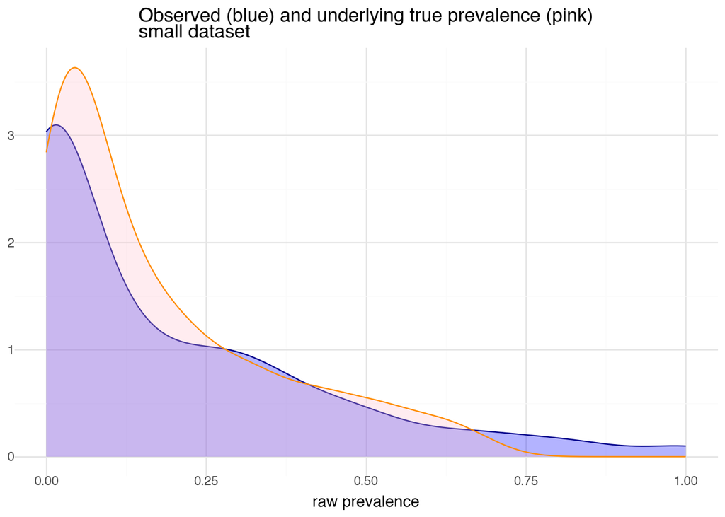

```python
sim_df = pd.DataFrame({'tests':sim_data.tests[0], 'pos_tests':sim_data.pos_tests[0], 'p_sample':sim_data.p_sample[0]})
sim_df['raw_prev'] = sim_df['pos_tests'] / sim_df['tests']
(
    p9.ggplot(sim_df)
    + p9.geom_density(p9.aes(x='raw_prev'), color='darkblue', fill='blue', alpha=0.3)
    + p9.geom_density(p9.aes(x='p_sample'), color='darkorange', fill='pink', alpha=0.3)
    + p9.labs(
        x='raw prevalence',
        y='',
        title='Observed (blue) and underlying true prevalence (pink)\nsmall dataset'
    )
    + p9.theme_minimal()
)
```

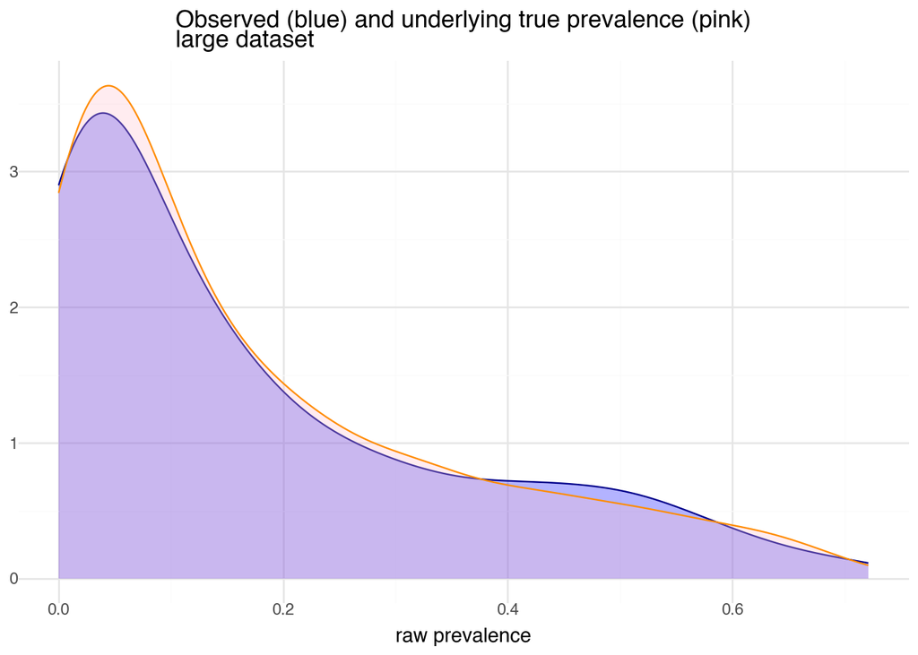

```python
sim_df = pd.DataFrame({'tests':sim_data_lg.tests[0], 'pos_tests':sim_data_lg.pos_tests[0], 'p_sample':sim_data_lg.p_sample[0]})
sim_df['raw_prev'] = sim_df['pos_tests'] / sim_df['tests']
(
    p9.ggplot(sim_df)
    + p9.geom_density(p9.aes(x='raw_prev'), color='darkblue', fill='blue', alpha=0.3)
    + p9.geom_density(p9.aes(x='p_sample'), color='darkorange', fill='pink', alpha=0.3)
    + p9.labs(
        x='raw prevalence',
        y='',
        title='Observed (blue) and underlying true prevalence (pink)\nlarge dataset'
    )
    + p9.theme_minimal()
)
```

### Model Fitting

Assemble the data dictionary of all input data for the model which solves the inverse problem - i.e., estimates regression coefficients given the observed data. We use the generated data as the inputs. Because the output files are real-valued outputs, regardless of variable element type, model data variables of type int need to be cast to int. Here all the observed data is count and categorial data.

```python
data_fixed = {'N':sim_data.pos_tests.shape[1],
              'N_age':gen_data_dict['N_age'],
              'N_eth':gen_data_dict['N_eth'],
              'N_edu':gen_data_dict['N_edu'],
              'sens': gen_data_dict['sens'],
              'spec': gen_data_dict['spec'],
              'intercept_prior_mean': gen_data_dict['baseline'],
              'intercept_prior_scale': 2.5}

data_small = data_fixed | {'pos_tests':sim_data.pos_tests[0].astype(int),
             'tests':sim_data.tests[0].astype(int),
             'sex':sim_data.sex[0].astype(int),
             'age':sim_data.age[0].astype(int),
             'eth':sim_data.eth[0].astype(int),
             'edu':sim_data.edu[0].astype(int)}

data_large = data_fixed | {'pos_tests':sim_data_lg.pos_tests[0].astype(int),
             'tests':sim_data_lg.tests[0].astype(int),
             'sex':sim_data_lg.sex[0].astype(int),
             'age':sim_data_lg.age[0].astype(int),
             'eth':sim_data_lg.eth[0].astype(int),
             'edu':sim_data_lg.edu[0].astype(int)}
```

Record the data-generating parameters

```python
true_params = {
    'beta_0': sim_data.beta_0[0],
    'pct_sex': sim_data.pct_sex[0],
    'beta_sex': sim_data.beta_sex[0],
    'pct_age': sim_data.pct_age[0],
    'beta_age':sim_data.beta_age[0],
    'pct_eth': sim_data.pct_eth[0],
    'beta_eth':sim_data.beta_eth[0],
    'pct_edu': sim_data.pct_edu[0],
    'beta_edu':sim_data.beta_edu[0]
}
true_params
```

```
{'beta_0': -3.5,
 'pct_sex': array([0.4, 0.6]),
 'beta_sex': 0.591981,
 'pct_age': array([0.11, 0.02, 0.1 , 0.15, 0.04, 0.14, 0.25, 0.12, 0.08]),
 'beta_age': array([-0.74, -1.43, -1.67,  1.  , -0.52, -0.77,  0.96,  1.31,  0.25]),
 'pct_eth': array([0.13, 0.64, 0.22]),
 'beta_eth': array([ 1.97, -0.8 ,  0.75]),
 'pct_edu': array([0.19, 0.24, 0.27, 0.09, 0.2 ]),
 'beta_edu': array([ 0.24, -0.22,  0.87, -0.85,  1.5 ])}
```

#### Model 1: `sum_to_zero_vector`

```python
binomial_ozs_mod = CmdStanModel(stan_file=os.path.join('stan', 'binomial_4preds_ozs.stan'))
```

```python
binomial_ozs_fit = binomial_ozs_mod.sample(data=data_small, parallel_chains=4)

print("sum_to_zero_vector: runtimes in seconds, all chains")
binomial_ozs_fit.time
```

```
10:54:55 - cmdstanpy - INFO - CmdStan start processing
```

```
10:54:56 - cmdstanpy - INFO - CmdStan done processing.
10:54:56 - cmdstanpy - WARNING - Non-fatal error during sampling:
Exception: normal_lpdf: Scale parameter is 0, but must be positive! (in 'binomial_4preds_ozs.stan', line 57, column 2 to column 42)
Exception: normal_lpdf: Scale parameter is 0, but must be positive! (in 'binomial_4preds_ozs.stan', line 55, column 2 to column 42)
Exception: normal_lpdf: Scale parameter is 0, but must be positive! (in 'binomial_4preds_ozs.stan', line 55, column 2 to column 42)
Consider re-running with show_console=True if the above output is unclear!
```

```
sum_to_zero_vector: runtimes in seconds, all chains
```

```
[{'warmup': 0.212, 'sampling': 0.306, 'total': 0.518},
 {'warmup': 0.203, 'sampling': 0.356, 'total': 0.559},
 {'warmup': 0.211, 'sampling': 0.345, 'total': 0.556},
 {'warmup': 0.21, 'sampling': 0.362, 'total': 0.572}]
```

Record the seed used for the first run and use it for all subsequent fits.

```python
a_seed = binomial_ozs_fit.metadata.cmdstan_config['seed']
```

```python
binomial_ozs_fit_lg = binomial_ozs_mod.sample(data=data_large, parallel_chains=4, seed=a_seed)

print("sum_to_zero_vector, large: runtimes in seconds, all chains")
binomial_ozs_fit_lg.time
```

```
10:54:56 - cmdstanpy - INFO - CmdStan start processing
```

```
10:54:56 - cmdstanpy - INFO - CmdStan done processing.
10:54:56 - cmdstanpy - WARNING - Non-fatal error during sampling:
Exception: normal_lpdf: Scale parameter is 0, but must be positive! (in 'binomial_4preds_ozs.stan', line 57, column 2 to column 42)
Exception: normal_lpdf: Scale parameter is 0, but must be positive! (in 'binomial_4preds_ozs.stan', line 55, column 2 to column 42)
Exception: normal_lpdf: Scale parameter is 0, but must be positive! (in 'binomial_4preds_ozs.stan', line 55, column 2 to column 42)
Consider re-running with show_console=True if the above output is unclear!
```

```
sum_to_zero_vector, large: runtimes in seconds, all chains
```

```
[{'warmup': 0.246, 'sampling': 0.367, 'total': 0.613},
 {'warmup': 0.235, 'sampling': 0.354, 'total': 0.589},
 {'warmup': 0.248, 'sampling': 0.35, 'total': 0.598},
 {'warmup': 0.233, 'sampling': 0.349, 'total': 0.582}]
```

#### Model 2: Hard sum-to-zero constraint

Run the sampler to get posterior estimates of the model conditioned on the data.

```python
binomial_hard_mod = CmdStanModel(stan_file=os.path.join('stan', 'binomial_4preds_hard.stan'))
```

```python
binomial_hard_fit = binomial_hard_mod.sample(data=data_small, parallel_chains=4, seed=a_seed)

print("hard sum-to-zero: runtimes in seconds, all chains")
binomial_hard_fit.time
```

```
10:54:57 - cmdstanpy - INFO - CmdStan start processing
```

```
10:54:57 - cmdstanpy - INFO - CmdStan done processing.
10:54:57 - cmdstanpy - WARNING - Non-fatal error during sampling:
Exception: normal_lpdf: Scale parameter is 0, but must be positive! (in 'binomial_4preds_hard.stan', line 46, column 2 to column 38)
Exception: normal_lpdf: Scale parameter is 0, but must be positive! (in 'binomial_4preds_hard.stan', line 44, column 2 to column 38)
Exception: normal_lpdf: Scale parameter is 0, but must be positive! (in 'binomial_4preds_hard.stan', line 44, column 2 to column 38)
Consider re-running with show_console=True if the above output is unclear!
```

```
hard sum-to-zero: runtimes in seconds, all chains
```

```
[{'warmup': 0.326, 'sampling': 0.456, 'total': 0.782},
 {'warmup': 0.327, 'sampling': 0.502, 'total': 0.829},
 {'warmup': 0.324, 'sampling': 0.409, 'total': 0.733},
 {'warmup': 0.327, 'sampling': 0.455, 'total': 0.782}]
```

```python
binomial_hard_fit_lg = binomial_hard_mod.sample(data=data_large, parallel_chains=4, seed=a_seed)

print("hard sum-to-zero, large: runtimes in seconds, all chains")
binomial_hard_fit_lg.time
```

```
10:54:57 - cmdstanpy - INFO - CmdStan start processing
```

```
10:54:58 - cmdstanpy - INFO - CmdStan done processing.
10:54:58 - cmdstanpy - WARNING - Non-fatal error during sampling:
Exception: normal_lpdf: Scale parameter is 0, but must be positive! (in 'binomial_4preds_hard.stan', line 46, column 2 to column 38)
Exception: normal_lpdf: Scale parameter is 0, but must be positive! (in 'binomial_4preds_hard.stan', line 44, column 2 to column 38)
Consider re-running with show_console=True if the above output is unclear!
```

```
hard sum-to-zero, large: runtimes in seconds, all chains
```

```
[{'warmup': 0.343, 'sampling': 0.459, 'total': 0.802},
 {'warmup': 0.39, 'sampling': 0.417, 'total': 0.807},
 {'warmup': 0.363, 'sampling': 0.421, 'total': 0.784},
 {'warmup': 0.368, 'sampling': 0.424, 'total': 0.792}]
```

#### Model 3: soft sum-to-zero constraint

```python
binomial_soft_mod = CmdStanModel(stan_file=os.path.join('stan', 'binomial_4preds_soft.stan'))
```

```python
binomial_soft_fit = binomial_soft_mod.sample(data=data_small, parallel_chains=4, seed=a_seed)

print("soft sum-to-zero: runtimes in seconds, all chains")
binomial_soft_fit.time
```

```
10:54:58 - cmdstanpy - INFO - CmdStan start processing
```

```
10:55:11 - cmdstanpy - INFO - CmdStan done processing.
10:55:11 - cmdstanpy - WARNING - Non-fatal error during sampling:
Exception: normal_lpdf: Scale parameter is 0, but must be positive! (in 'binomial_4preds_soft.stan', line 46, column 2 to column 34)
Exception: normal_lpdf: Scale parameter is 0, but must be positive! (in 'binomial_4preds_soft.stan', line 44, column 2 to column 34)
Consider re-running with show_console=True if the above output is unclear!
```

```
soft sum-to-zero: runtimes in seconds, all chains
```

```
[{'warmup': 5.428, 'sampling': 7.254, 'total': 12.682},
 {'warmup': 5.279, 'sampling': 5.124, 'total': 10.403},
 {'warmup': 5.704, 'sampling': 6.237, 'total': 11.941},
 {'warmup': 5.373, 'sampling': 6.026, 'total': 11.399}]
```

```python
binomial_soft_fit_lg = binomial_soft_mod.sample(data=data_large, parallel_chains=4, seed=a_seed)

print("soft sum-to-zero, large: runtimes in seconds, all chains")
binomial_soft_fit_lg.time
```

```
10:55:11 - cmdstanpy - INFO - CmdStan start processing
```

```
10:55:15 - cmdstanpy - INFO - CmdStan done processing.
10:55:15 - cmdstanpy - WARNING - Non-fatal error during sampling:
Exception: normal_lpdf: Scale parameter is 0, but must be positive! (in 'binomial_4preds_soft.stan', line 46, column 2 to column 34)
Exception: normal_lpdf: Scale parameter is 0, but must be positive! (in 'binomial_4preds_soft.stan', line 44, column 2 to column 34)
Consider re-running with show_console=True if the above output is unclear!
```

```
soft sum-to-zero, large: runtimes in seconds, all chains
```

```
[{'warmup': 1.763, 'sampling': 2.138, 'total': 3.901},
 {'warmup': 1.907, 'sampling': 2.098, 'total': 4.005},
 {'warmup': 1.736, 'sampling': 1.876, 'total': 3.612},
 {'warmup': 1.88, 'sampling': 2.042, 'total': 3.922}]
```

#### Runtime performance

In the small data regime, the soft-sum to zero takes considerably more wall-clock time to fit the data. On Apple M3 hardware, all three models quickly fit the large dataset.

### Model Checking and Comparison

#### Check convergence

We check the R-hat and effective sample size (ESS) for all group-level parameters.

In order to do this multiway comparison, we assemble the individual summaries from the 6 runs above into two dataframes. We also compute the number of effective samples per second - a key metric of model efficienty. (Note: we’re using a development version of CmdStanPy to scrape time information from the CSV files because changes to CmdStan’s `stansummary` function removed the ESS/sec metric. This is a workaround for now).

```python
# small dataset
ozs_fit_summary = binomial_ozs_fit.summary(sig_figs=2)
ozs_fit_summary.index =  ozs_fit_summary.index.astype(str) + "  a) ozs"
ozs_fit_time = binomial_ozs_fit.time
ozs_total_time = 0
for i in range(len(ozs_fit_time)):
    ozs_total_time += ozs_fit_time[i]['total']
ozs_fit_summary['ESS/sec'] = ozs_fit_summary['ESS_bulk']/ozs_total_time

hard_fit_summary = binomial_hard_fit.summary(sig_figs=2)
hard_fit_summary.index = hard_fit_summary.index.astype(str) + "  b) hard"
hard_fit_time = binomial_hard_fit.time
hard_total_time = 0
for i in range(len(hard_fit_time)):
    hard_total_time += hard_fit_time[i]['total']
hard_fit_summary['ESS/sec'] = hard_fit_summary['ESS_bulk']/hard_total_time

soft_fit_summary = binomial_soft_fit.summary(sig_figs=2)
soft_fit_summary.index = soft_fit_summary.index.astype(str) + "  c) soft"
soft_fit_time = binomial_soft_fit.time
soft_total_time = 0
for i in range(len(soft_fit_time)):
    soft_total_time += soft_fit_time[i]['total']
soft_fit_summary['ESS/sec'] = soft_fit_summary['ESS_bulk']/soft_total_time

small_data_fits_summary = pd.concat([ozs_fit_summary, hard_fit_summary, soft_fit_summary])

# large dataset
ozs_fit_lg_summary = binomial_ozs_fit_lg.summary(sig_figs=2)
ozs_fit_lg_summary.index =  ozs_fit_lg_summary.index.astype(str) + "  a) ozs"
ozs_fit_time_lg = binomial_ozs_fit_lg.time
ozs_total_time_lg = 0
for i in range(len(ozs_fit_time_lg)):
    ozs_total_time_lg += ozs_fit_time_lg[i]['total']
ozs_fit_lg_summary['ESS/sec'] = ozs_fit_lg_summary['ESS_bulk']/ozs_total_time_lg

hard_fit_lg_summary = binomial_hard_fit_lg.summary(sig_figs=2)
hard_fit_lg_summary.index = hard_fit_lg_summary.index.astype(str) + "  b) hard"
hard_fit_time_lg = binomial_hard_fit_lg.time
hard_total_time_lg = 0
for i in range(len(hard_fit_time_lg)):
    hard_total_time_lg += hard_fit_time_lg[i]['total']
hard_fit_lg_summary['ESS/sec'] = hard_fit_lg_summary['ESS_bulk']/hard_total_time_lg

soft_fit_lg_summary = binomial_soft_fit_lg.summary(sig_figs=2)
soft_fit_lg_summary.index = soft_fit_lg_summary.index.astype(str) + "  c) soft"
soft_fit_time_lg = binomial_soft_fit_lg.time
soft_total_time_lg = 0
for i in range(len(soft_fit_time_lg)):
    soft_total_time_lg += soft_fit_time_lg[i]['total']
soft_fit_lg_summary['ESS/sec'] = soft_fit_lg_summary['ESS_bulk']/soft_total_time_lg

large_data_fits_summary = pd.concat([ozs_fit_lg_summary, hard_fit_lg_summary, soft_fit_lg_summary])
```

**Eth**

```python
beta_eth_summary = summarize_predictor(small_data_fits_summary, 'beta_eth\[')
beta_eth_summary_lg = summarize_predictor(large_data_fits_summary, 'beta_eth\[')
```

```python
small_html = style_dataframe(beta_eth_summary, 3).to_html()
large_html = style_dataframe(beta_eth_summary_lg, 3).to_html()
display_side_by_side(small_html, large_html)
```

*Small Dataset*

|  | Mean | StdDev | ESS_bulk | ESS/sec | R_hat |
| --- | --- | --- | --- | --- | --- |
| beta_eth[1] a) ozs | 1.40 | 0.10 | 3900.00 | 1768.71 | 1.00 |
| beta_eth[1] b) hard | 1.40 | 0.10 | 2900.00 | 927.70 | 1.00 |
| beta_eth[1] c) soft | 1.40 | 0.11 | 2300.00 | 49.54 | 1.00 |
| beta_eth[2] a) ozs | -1.50 | 0.08 | 4400.00 | 1995.46 | 1.00 |
| beta_eth[2] b) hard | -1.50 | 0.09 | 3000.00 | 959.69 | 1.00 |
| beta_eth[2] c) soft | -1.50 | 0.08 | 2500.00 | 53.85 | 1.00 |
| beta_eth[3] a) ozs | 0.10 | 0.08 | 4700.00 | 2131.52 | 1.00 |
| beta_eth[3] b) hard | 0.10 | 0.08 | 7500.00 | 2399.23 | 1.00 |
| beta_eth[3] c) soft | 0.10 | 0.08 | 2900.00 | 62.47 | 1.00 |

*Large Dataset*

|  | Mean | StdDev | ESS_bulk | ESS/sec | R_hat |
| --- | --- | --- | --- | --- | --- |
| beta_eth[1] a) ozs | 1.30 | 0.03 | 4000.00 | 1679.26 | 1.00 |
| beta_eth[1] b) hard | 1.30 | 0.03 | 3500.00 | 1098.90 | 1.00 |
| beta_eth[1] c) soft | 1.30 | 0.03 | 3300.00 | 213.73 | 1.00 |
| beta_eth[2] a) ozs | -1.50 | 0.02 | 4400.00 | 1847.19 | 1.00 |
| beta_eth[2] b) hard | -1.50 | 0.02 | 3600.00 | 1130.30 | 1.00 |
| beta_eth[2] c) soft | -1.50 | 0.02 | 4100.00 | 265.54 | 1.00 |
| beta_eth[3] a) ozs | 0.17 | 0.02 | 4300.00 | 1805.21 | 1.00 |
| beta_eth[3] b) hard | 0.17 | 0.02 | 8000.00 | 2511.77 | 1.00 |
| beta_eth[3] c) soft | 0.17 | 0.02 | 4600.00 | 297.93 | 1.00 |

```python
print("params", true_params['beta_eth'], "\npcts", true_params['pct_eth'])
```

```
params [ 1.97 -0.8   0.75]
pcts [0.13 0.64 0.22]
```

```python
sigma_eth_summary = summarize_predictor(small_data_fits_summary, 'sigma_eth')
sigma_eth_summary_lg = summarize_predictor(large_data_fits_summary, 'sigma_eth')

small_html = style_dataframe(sigma_eth_summary, 3).to_html()
large_html = style_dataframe(sigma_eth_summary_lg, 3).to_html()
display_side_by_side(small_html, large_html)
```

*Small Dataset*

|  | Mean | StdDev | ESS_bulk | ESS/sec | R_hat |
| --- | --- | --- | --- | --- | --- |
| sigma_eth a) ozs | 1.10 | 0.39 | 5200.00 | 2358.28 | 1.00 |
| sigma_eth b) hard | 1.40 | 0.45 | 4900.00 | 1567.50 | 1.00 |
| sigma_eth c) soft | 1.20 | 0.40 | 4300.00 | 92.62 | 1.00 |

*Large Dataset*

|  | Mean | StdDev | ESS_bulk | ESS/sec | R_hat |
| --- | --- | --- | --- | --- | --- |
| sigma_eth a) ozs | 1.00 | 0.38 | 5300.00 | 2225.02 | 1.00 |
| sigma_eth b) hard | 1.30 | 0.44 | 6500.00 | 2040.82 | 1.00 |
| sigma_eth c) soft | 1.20 | 0.40 | 6300.00 | 408.03 | 1.00 |

**Edu**

```python
beta_edu_summary = summarize_predictor(small_data_fits_summary, 'beta_edu\[')
beta_edu_summary_lg = summarize_predictor(large_data_fits_summary, 'beta_edu\[')
```

```python
small_html = style_dataframe(beta_edu_summary, 3).to_html()
large_html = style_dataframe(beta_edu_summary_lg, 3).to_html()
display_side_by_side(small_html, large_html)
```

*Small Dataset*

|  | Mean | StdDev | ESS_bulk | ESS/sec | R_hat |
| --- | --- | --- | --- | --- | --- |
| beta_edu[1] a) ozs | -0.18 | 0.12 | 4600.00 | 2086.17 | 1.00 |
| beta_edu[1] b) hard | -0.19 | 0.12 | 3900.00 | 1247.60 | 1.00 |
| beta_edu[1] c) soft | -0.18 | 0.12 | 3800.00 | 81.85 | 1.00 |
| beta_edu[2] a) ozs | -0.36 | 0.12 | 5700.00 | 2585.03 | 1.00 |
| beta_edu[2] b) hard | -0.37 | 0.12 | 3600.00 | 1151.63 | 1.00 |
| beta_edu[2] c) soft | -0.36 | 0.12 | 3400.00 | 73.24 | 1.00 |
| beta_edu[3] a) ozs | 0.63 | 0.10 | 4600.00 | 2086.17 | 1.00 |
| beta_edu[3] b) hard | 0.62 | 0.11 | 3500.00 | 1119.64 | 1.00 |
| beta_edu[3] c) soft | 0.63 | 0.10 | 2900.00 | 62.47 | 1.00 |
| beta_edu[4] a) ozs | -1.20 | 0.21 | 3300.00 | 1496.60 | 1.00 |
| beta_edu[4] b) hard | -1.20 | 0.22 | 2600.00 | 831.73 | 1.00 |
| beta_edu[4] c) soft | -1.20 | 0.21 | 2200.00 | 47.39 | 1.00 |
| beta_edu[5] a) ozs | 1.10 | 0.11 | 3500.00 | 1587.30 | 1.00 |
| beta_edu[5] b) hard | 1.10 | 0.11 | 3900.00 | 1247.60 | 1.00 |
| beta_edu[5] c) soft | 1.10 | 0.11 | 3200.00 | 68.93 | 1.00 |

*Large Dataset*

|  | Mean | StdDev | ESS_bulk | ESS/sec | R_hat |
| --- | --- | --- | --- | --- | --- |
| beta_edu[1] a) ozs | -0.05 | 0.04 | 4700.00 | 1973.13 | 1.00 |
| beta_edu[1] b) hard | -0.05 | 0.04 | 4900.00 | 1538.46 | 1.00 |
| beta_edu[1] c) soft | -0.05 | 0.04 | 5900.00 | 382.12 | 1.00 |
| beta_edu[2] a) ozs | -0.53 | 0.04 | 5000.00 | 2099.08 | 1.00 |
| beta_edu[2] b) hard | -0.53 | 0.04 | 4900.00 | 1538.46 | 1.00 |
| beta_edu[2] c) soft | -0.53 | 0.04 | 5600.00 | 362.69 | 1.00 |
| beta_edu[3] a) ozs | 0.60 | 0.03 | 4000.00 | 1679.26 | 1.00 |
| beta_edu[3] b) hard | 0.60 | 0.03 | 3900.00 | 1224.49 | 1.00 |
| beta_edu[3] c) soft | 0.60 | 0.03 | 4600.00 | 297.93 | 1.00 |
| beta_edu[4] a) ozs | -1.20 | 0.06 | 3900.00 | 1637.28 | 1.00 |
| beta_edu[4] b) hard | -1.20 | 0.06 | 2900.00 | 910.52 | 1.00 |
| beta_edu[4] c) soft | -1.20 | 0.06 | 4000.00 | 259.07 | 1.00 |
| beta_edu[5] a) ozs | 1.20 | 0.03 | 4000.00 | 1679.26 | 1.00 |
| beta_edu[5] b) hard | 1.20 | 0.03 | 3900.00 | 1224.49 | 1.00 |
| beta_edu[5] c) soft | 1.20 | 0.03 | 4800.00 | 310.88 | 1.00 |

```python
print("params", true_params['beta_edu'], "\npcts", true_params['pct_edu'])
```

```
params [ 0.24 -0.22  0.87 -0.85  1.5 ]
pcts [0.19 0.24 0.27 0.09 0.2 ]
```

```python
sigma_edu_summary = summarize_predictor(small_data_fits_summary, 'sigma_edu')
sigma_edu_summary_lg = summarize_predictor(large_data_fits_summary, 'sigma_edu')

small_html = style_dataframe(sigma_edu_summary, 3).to_html()
large_html = style_dataframe(sigma_edu_summary_lg, 3).to_html()
display_side_by_side(small_html, large_html)
```

*Small Dataset*

|  | Mean | StdDev | ESS_bulk | ESS/sec | R_hat |
| --- | --- | --- | --- | --- | --- |
| sigma_edu a) ozs | 0.84 | 0.29 | 4600.00 | 2086.17 | 1.00 |
| sigma_edu b) hard | 0.86 | 0.32 | 4200.00 | 1343.57 | 1.00 |
| sigma_edu c) soft | 0.91 | 0.30 | 4100.00 | 88.31 | 1.00 |

*Large Dataset*

|  | Mean | StdDev | ESS_bulk | ESS/sec | R_hat |
| --- | --- | --- | --- | --- | --- |
| sigma_edu a) ozs | 0.89 | 0.29 | 4600.00 | 1931.15 | 1.00 |
| sigma_edu b) hard | 0.88 | 0.33 | 7000.00 | 2197.80 | 1.00 |
| sigma_edu c) soft | 0.96 | 0.30 | 5400.00 | 349.74 | 1.00 |

**Age**

```python
beta_age_summary = summarize_predictor(small_data_fits_summary, 'beta_age\[')
beta_age_summary_lg = summarize_predictor(large_data_fits_summary, 'beta_age\[')
```

```python
small_html = style_dataframe(beta_age_summary, 3).to_html()
large_html = style_dataframe(beta_age_summary_lg, 3).to_html()
display_side_by_side(small_html, large_html)
```

*Small Dataset*

|  | Mean | StdDev | ESS_bulk | ESS/sec | R_hat |
| --- | --- | --- | --- | --- | --- |
| beta_age[1] a) ozs | -0.78 | 0.20 | 5700.00 | 2585.03 | 1.00 |
| beta_age[1] b) hard | -0.78 | 0.20 | 3900.00 | 1247.60 | 1.00 |
| beta_age[1] c) soft | -0.78 | 0.21 | 3500.00 | 75.39 | 1.00 |
| beta_age[2] a) ozs | -1.20 | 0.56 | 1900.00 | 861.68 | 1.00 |
| beta_age[2] b) hard | -1.20 | 0.55 | 1800.00 | 575.82 | 1.00 |
| beta_age[2] c) soft | -1.10 | 0.54 | 1900.00 | 40.93 | 1.00 |
| beta_age[3] a) ozs | -1.30 | 0.25 | 5200.00 | 2358.28 | 1.00 |
| beta_age[3] b) hard | -1.30 | 0.24 | 4200.00 | 1343.57 | 1.00 |
| beta_age[3] c) soft | -1.30 | 0.24 | 4400.00 | 94.78 | 1.00 |
| beta_age[4] a) ozs | 1.20 | 0.14 | 3100.00 | 1405.90 | 1.00 |
| beta_age[4] b) hard | 1.20 | 0.15 | 2600.00 | 831.73 | 1.00 |
| beta_age[4] c) soft | 1.20 | 0.14 | 2800.00 | 60.31 | 1.00 |
| beta_age[5] a) ozs | 0.04 | 0.27 | 4300.00 | 1950.11 | 1.00 |
| beta_age[5] b) hard | 0.04 | 0.28 | 3900.00 | 1247.60 | 1.00 |
| beta_age[5] c) soft | 0.03 | 0.28 | 3900.00 | 84.01 | 1.00 |
| beta_age[6] a) ozs | -0.79 | 0.18 | 4100.00 | 1859.41 | 1.00 |
| beta_age[6] b) hard | -0.79 | 0.19 | 3300.00 | 1055.66 | 1.00 |
| beta_age[6] c) soft | -0.79 | 0.18 | 3800.00 | 81.85 | 1.00 |
| beta_age[7] a) ozs | 0.94 | 0.13 | 2900.00 | 1315.19 | 1.00 |
| beta_age[7] b) hard | 0.95 | 0.13 | 2200.00 | 703.77 | 1.00 |
| beta_age[7] c) soft | 0.93 | 0.13 | 2500.00 | 53.85 | 1.00 |
| beta_age[8] a) ozs | 1.20 | 0.16 | 2900.00 | 1315.19 | 1.00 |
| beta_age[8] b) hard | 1.20 | 0.16 | 2600.00 | 831.73 | 1.00 |
| beta_age[8] c) soft | 1.10 | 0.16 | 3300.00 | 71.08 | 1.00 |
| beta_age[9] a) ozs | 0.69 | 0.18 | 3800.00 | 1723.36 | 1.00 |
| beta_age[9] b) hard | 0.71 | 0.18 | 3700.00 | 1183.62 | 1.00 |
| beta_age[9] c) soft | 0.68 | 0.18 | 3400.00 | 73.24 | 1.00 |

*Large Dataset*

|  | Mean | StdDev | ESS_bulk | ESS/sec | R_hat |
| --- | --- | --- | --- | --- | --- |
| beta_age[1] a) ozs | -0.59 | 0.06 | 5700.00 | 2392.95 | 1.00 |
| beta_age[1] b) hard | -0.59 | 0.06 | 5000.00 | 1569.86 | 1.00 |
| beta_age[1] c) soft | -0.58 | 0.06 | 5400.00 | 349.74 | 1.00 |
| beta_age[2] a) ozs | -1.30 | 0.16 | 1800.00 | 755.67 | 1.00 |
| beta_age[2] b) hard | -1.30 | 0.16 | 2100.00 | 659.34 | 1.00 |
| beta_age[2] c) soft | -1.30 | 0.16 | 3200.00 | 207.25 | 1.00 |
| beta_age[3] a) ozs | -1.50 | 0.08 | 5300.00 | 2225.02 | 1.00 |
| beta_age[3] b) hard | -1.50 | 0.08 | 5900.00 | 1852.43 | 1.00 |
| beta_age[3] c) soft | -1.50 | 0.08 | 5400.00 | 349.74 | 1.00 |
| beta_age[4] a) ozs | 1.20 | 0.04 | 3400.00 | 1427.37 | 1.00 |
| beta_age[4] b) hard | 1.20 | 0.04 | 3000.00 | 941.92 | 1.00 |
| beta_age[4] c) soft | 1.20 | 0.04 | 4400.00 | 284.97 | 1.00 |
| beta_age[5] a) ozs | -0.28 | 0.09 | 4900.00 | 2057.09 | 1.00 |
| beta_age[5] b) hard | -0.28 | 0.09 | 6400.00 | 2009.42 | 1.00 |
| beta_age[5] c) soft | -0.28 | 0.08 | 5500.00 | 356.22 | 1.00 |
| beta_age[6] a) ozs | -0.62 | 0.06 | 4200.00 | 1763.22 | 1.00 |
| beta_age[6] b) hard | -0.62 | 0.05 | 4700.00 | 1475.67 | 1.00 |
| beta_age[6] c) soft | -0.62 | 0.05 | 5000.00 | 323.83 | 1.00 |
| beta_age[7] a) ozs | 1.10 | 0.04 | 2700.00 | 1133.50 | 1.00 |
| beta_age[7] b) hard | 1.10 | 0.04 | 2500.00 | 784.93 | 1.00 |
| beta_age[7] c) soft | 1.10 | 0.04 | 3600.00 | 233.16 | 1.00 |
| beta_age[8] a) ozs | 1.50 | 0.05 | 2800.00 | 1175.48 | 1.00 |
| beta_age[8] b) hard | 1.50 | 0.04 | 3100.00 | 973.31 | 1.00 |
| beta_age[8] c) soft | 1.50 | 0.05 | 4300.00 | 278.50 | 1.00 |
| beta_age[9] a) ozs | 0.45 | 0.06 | 3200.00 | 1343.41 | 1.00 |
| beta_age[9] b) hard | 0.45 | 0.06 | 4400.00 | 1381.48 | 1.00 |
| beta_age[9] c) soft | 0.45 | 0.06 | 5200.00 | 336.79 | 1.00 |

```python
print("params", true_params['beta_age'], "\npcts", true_params['pct_age'])
```

```
params [-0.74 -1.43 -1.67  1.   -0.52 -0.77  0.96  1.31  0.25]
pcts [0.11 0.02 0.1  0.15 0.04 0.14 0.25 0.12 0.08]
```

```python
sigma_age_summary = summarize_predictor(small_data_fits_summary, 'sigma_age')
sigma_age_summary_lg = summarize_predictor(large_data_fits_summary, 'sigma_age')

small_html = style_dataframe(sigma_age_summary, 3).to_html()
large_html = style_dataframe(sigma_age_summary_lg, 3).to_html()
display_side_by_side(small_html, large_html)
```

*Small Dataset*

|  | Mean | StdDev | ESS_bulk | ESS/sec | R_hat |
| --- | --- | --- | --- | --- | --- |
| sigma_age a) ozs | 1.00 | 0.26 | 3900.00 | 1768.71 | 1.00 |
| sigma_age b) hard | 1.10 | 0.29 | 3400.00 | 1087.65 | 1.00 |
| sigma_age c) soft | 1.00 | 0.27 | 3500.00 | 75.39 | 1.00 |

*Large Dataset*

|  | Mean | StdDev | ESS_bulk | ESS/sec | R_hat |
| --- | --- | --- | --- | --- | --- |
| sigma_age a) ozs | 1.00 | 0.25 | 4900.00 | 2057.09 | 1.00 |
| sigma_age b) hard | 1.20 | 0.28 | 5500.00 | 1726.84 | 1.00 |
| sigma_age c) soft | 1.10 | 0.25 | 5800.00 | 375.65 | 1.00 |

All models have R-hat values of 1.00 for all group-level parameters and high effective sample sizes.

#### Calibration check

All models contain a `generated quantities` block, which creates `y_rep`, the [posterior predictive sample](https://mc-stan.org/docs/stan-users-guide/posterior-prediction.html). If the model is well-calibrated for the data, we expect that at least 50% of the time the observed value of `y` will fall in the central 50% interval of the `y_rep` sample estimates.

```python
from utils_dataviz import ppc_central_interval

y_rep_ozs = binomial_ozs_fit.y_rep.astype(int)
print("sum_to_zero_vector fit", ppc_central_interval(y_rep_ozs, sim_data.pos_tests[0]))

y_rep_hard = binomial_hard_fit.y_rep.astype(int)
print("Hard sum-to-zero fit", ppc_central_interval(y_rep_hard, sim_data.pos_tests[0]))

y_rep_soft = binomial_soft_fit.y_rep.astype(int)
print("Soft sum-to-zero fit", ppc_central_interval(y_rep_soft, sim_data.pos_tests[0]))
```

```
sum_to_zero_vector fit y total: 270, ct y is within y_rep central 50% interval: 225, pct: 83.33
Hard sum-to-zero fit y total: 270, ct y is within y_rep central 50% interval: 224, pct: 82.96
Soft sum-to-zero fit y total: 270, ct y is within y_rep central 50% interval: 223, pct: 82.59
```

### Visualize the fit

Plot the distribution of the actual data against the predicted data values for a random sample of replicates. In file `utils_dataviz.py` we have implemented the equivalent of the R `bayesplot` package function `ppc_dens_overlay`.

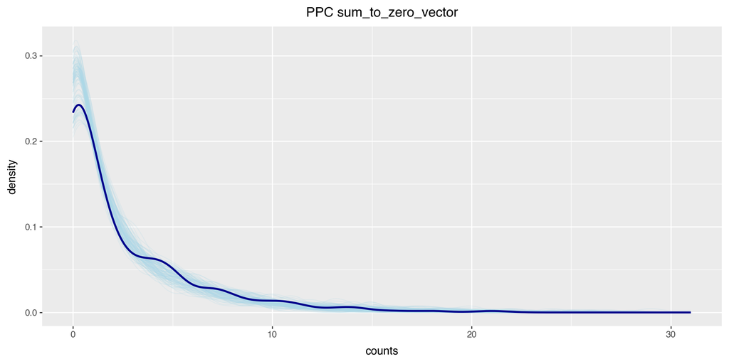

```python
from utils_dataviz import ppc_dens_overlay
yrep_ozs = binomial_ozs_fit.stan_variable('y_rep')
ppc_plot_ozs = ppc_dens_overlay(sim_data.pos_tests[0].astype('int'), yrep_ozs, 100, 'PPC sum_to_zero_vector', 'counts')
ppc_plot_ozs
```

### Discussion

For the multi-level model, the `sum_to_zero_vector` provides the fastest wall-clock time for both datasets.

## Spatial Models with an ICAR component

Spatial auto-correlation is the tendency for adjacent areas to share similar characteristics. Conditional Auto-Regressive (CAR) and Intrinsic Conditional Auto-Regressive (ICAR) models, first introduced by Besag, 1974, account for this by pooling information from neighboring regions. The BYM model, (Besag, York, Mollié, 1991) extends a lognormal Poisson model plus ICAR component for spatial auto-correlation by adding an ordinary random-effects component for non-spatial heterogeneity. The BYM2 model builds on this model and subsequent refinements.

These models are more fully explained in a series of notebooks available from GitHub repo: https://github.com/mitzimorris/geomed_2024, see notebooks: * [The ICAR model in Stan](https://github.com/mitzimorris/geomed_2024/blob/main/python-notebooks/h4_icar.ipynb) * [The BYM2 model in Stan](https://github.com/mitzimorris/geomed_2024/blob/main/python-notebooks/h5_bym2.ipynb) * [The BYM2_multicomp model in Stan](https://github.com/mitzimorris/geomed_2024/blob/main/python-notebooks/h6_bym2_multicomp.ipynb)

### Example dataset: New York City traffic accidents

The dataset we’re using is that used in the analysis published in 2019 [Bayesian Hierarchical Spatial Models: Implementing the Besag York Mollié Model in Stan](https://www.sciencedirect.com/science/article/pii/S1877584518301175).

The data consists of motor vehicle collisions in New York City, as recorded by the NYC Department of Transportation, between the years 2005-2014, restricted to collisions involving school age children 5-18 years of age as pedestrians. Each crash was localized to the US Census tract in which it occurred, using boundaries from the 2010 United States Census, using the [2010 Census block map for New York City](https://data.cityofnewyork.us/City-Government/2010-Census-Blocks/v2h8-6mxf). File `data/nyc_study.geojson` contains the study data and census tract ids and geometry.

```python
nyc_geodata = gpd.read_file(os.path.join('data', 'nyc_study.geojson'))
nyc_geodata.columns
nyc_geodata[['BoroName', 'NTAName', 'count', 'kid_pop']].head(4)
```

|  | BoroName | NTAName | count | kid_pop |
| --- | --- | --- | --- | --- |
| 0 | Bronx | Soundview-Castle Hill-Clason Point-Harding Park | 9.00 | 894.00 |
| 1 | Bronx | Soundview-Castle Hill-Clason Point-Harding Park | 12.00 | 1158.00 |
| 2 | Bronx | Soundview-Castle Hill-Clason Point-Harding Park | 28.00 | 1120.00 |
| 3 | Bronx | Mott Haven-Port Morris | 14.00 | 281.00 |

The shapefiles from the Census Bureau connect Manhattan to Brooklyn and Queens, but for this analysis, Manhattan is quite separate from Brooklyn and Queens. Getting the data assembled in the order required for our analysis requires data munging, encapsulated in the Python functions in file `utils_nyc_map.py`. The function `nyc_sort_by_comp_size` removes any neighbor pairs between tracts in Manhattan and any tracts in Brooklyn or Queens and updates the neighbor graph accordingly. It returns a clean neighbor graph and the corresponding geodataframe, plus a list of the component sizes. The list is sorted so that the largest component (Brooklyn and Queens) is first, and singleton nodes are last.

```python
from utils_nyc_map import nyc_sort_by_comp_size

(nyc_nbs, nyc_gdf, nyc_comp_sizes) = nyc_sort_by_comp_size(nyc_geodata)
nyc_comp_sizes
```

```
[1360, 329, 271, 108, 22, 2, 1, 1, 1]
```

To check our work we examine both the geodataframe and the map.

```python
nyc_gdf[['BoroName', 'NTAName', 'count', 'kid_pop']].head(4)
```

|  | BoroName | NTAName | count | kid_pop |
| --- | --- | --- | --- | --- |
| 0 | Brooklyn | East New York | 6.00 | 432.00 |
| 1 | Brooklyn | Flatbush | 18.00 | 618.00 |
| 2 | Brooklyn | Erasmus | 15.00 | 891.00 |
| 3 | Brooklyn | Flatbush | 16.00 | 655.00 |

```python
nyc_gdf[['BoroName', 'NTAName', 'count', 'kid_pop']].tail(4)
```

|  | BoroName | NTAName | count | kid_pop |
| --- | --- | --- | --- | --- |
| 2091 | Manhattan | Lenox Hill-Roosevelt Island | 1.00 | 1134.00 |
| 2092 | Queens | Breezy Point-Belle Harbor-Rockaway Park-Broad ... | 3.00 | 402.00 |
| 2093 | Queens | Breezy Point-Belle Harbor-Rockaway Park-Broad ... | 1.00 | 609.00 |
| 2094 | Bronx | Pelham Bay-Country Club-City Island | 6.00 | 565.00 |

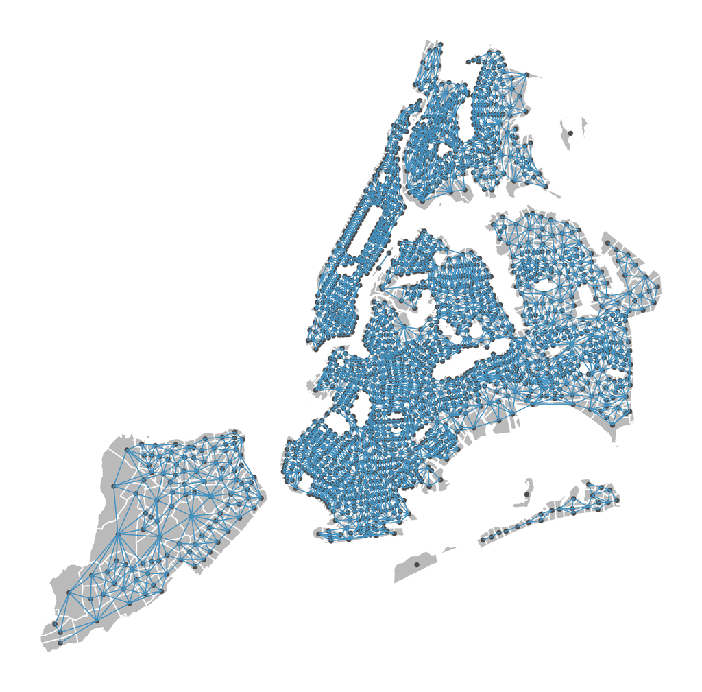

```python
from splot.libpysal import plot_spatial_weights
plot_spatial_weights(nyc_nbs, nyc_gdf)
```

### Model 1: The BYM2 model, Riebler et al. 2016

The key element of the BYM2 model is the ICAR component. Its conditional specification is a multivariate normal random vector $\mathbf{\phi}$ where each ${\phi}_i$ is conditional on the values of its neighbors.

The joint specification rewrites to a *Pairwise Difference*,

$$p(\phi) \propto \exp \left\{ {- \frac{1}{2}} \sum_{i \sim j}{({\phi}_i - {\phi}_j)}^2 \right\}$$

Each ${({\phi}_i - {\phi}_j)}^2$ contributes a penalty term based on the distance between the values of neighboring regions. However, $\phi$ is non-identifiable, constant added to $\phi$ washes out of ${\phi}_i - {\phi}_j$. Therefore, a sum-to-zero constraint is needed to both identify and center $\phi$.

The Stan implementation of the ICAR component computes the sum of the pairwise distances by representing the spatial adjacency matrix as a array of pairs of neighbor indices.

```stan
data {
  ...
  // spatial structure
  int<lower = 0> N_edges;  // number of neighbor pairs
  array[2, N_edges] int<lower = 1, upper = N> neighbors;  // columnwise adjacent
```

The ICAR prior comes into the model as parameter `phi`.

```stan
model {
  ...
  target += -0.5 * dot_self(phi[neighbors[1]] - phi[neighbors[2]]);  // ICAR prior
```

In this section, we compare three ways of implementing the sum-to-zero constraint on `phi`.

```stan
  target += (-0.5 * dot_self(phi[neighbors[1]] - phi[neighbors[2]])
         + normal_lupdf(sum(phi) | 0, 0.001 * rows(phi)));
```

The ICAR model requires that the neighbor graph is fully connected for two reasons:

- The joint distribution is computed from the pairwise differences between a node and its neighbors; singleton nodes have no neighbors and are therefore undefined.
- Even if the graph doesn’t have any singleton nodes, when the graph has multiple connected components a sum-to-zero constraint on the entire vector fails to properly identify the model.

Because the BYM2 model includes an ICAR component, it too requires a fully connected neighbor graph. We can either artifically connect the map, or we can analyze the NYC dataset on a per-component basis, starting with the largest component which encompasses Brooklyn and Queens (excepting the Rockaways).

```
number of components: 1
islands? []
max number of neighbors per node: 14
mean number of neighbors per node: 5.977941176470588
```

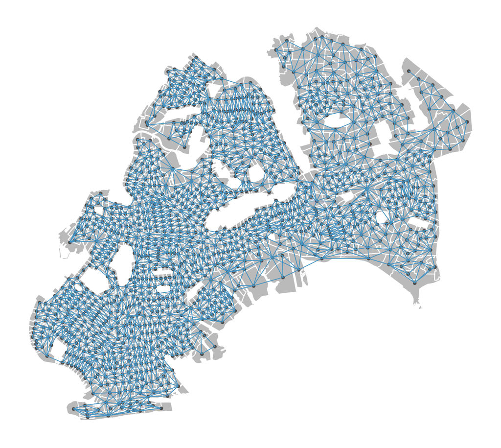

```python
from libpysal.weights import Queen
brklyn_qns_gdf = nyc_gdf[nyc_gdf['comp_id']==0].reset_index(drop=True)
brklyn_qns_nbs = Queen.from_dataframe(brklyn_qns_gdf , geom_col='geometry')
plot_spatial_weights(brklyn_qns_nbs, brklyn_qns_gdf )

print(f'number of components: {brklyn_qns_nbs.n_components}')
print(f'islands? {brklyn_qns_nbs.islands}')
print(f'max number of neighbors per node: {brklyn_qns_nbs.max_neighbors}')
print(f'mean number of neighbors per node: {brklyn_qns_nbs.mean_neighbors}')
```

#### Data assembly

The inputs to the BYM2 model are

- The Poisson regression data
  - `int<lower=0> N` - number of regions
  - `array[N] int<lower=0> y` - per-region count outcome
  - `vector<lower=0>[N] E` - the population of each region (a.k.a. “exposure”),
  - `int<lower=1> K` - the number of predictors
  - `matrix[N, K] xs` - the design matrix
- The spatial structure
  - `int<lower = 0> N_edges` - the number of neighbor pairs
  - `array[2, N_edges] int<lower = 1, upper = N> neighbors` - the graph structure
  - `real tau` - the scaling factor, introduced in the BYM2

The scaling factor `tau` was introduced by Reibler et al so that the variance of the spatial and ordinary random effects are both approximately equal to 1, thus allowing for a straightforward estimate of the amount of spatial and non-spatial variance. We have written a helper function called `get_scaling_factor`, in file `utils_bym2.py` which takes as its argument the neighbor graph and computes the geometric mean of the corresponding adjacency matrix.

```python
from utils_bym2 import get_scaling_factor, nbs_to_adjlist

# design matrix
design_vars = np.array(['pct_pubtransit','med_hh_inc', 'traffic', 'frag_index'])
design_mat = brklyn_qns_gdf[design_vars].to_numpy()
design_mat[:, 1] = np.log(design_mat[:, 1])
design_mat[:, 2] = np.log(design_mat[:, 2])

# neighbors array
brklyn_qns_nbs_adj = nbs_to_adjlist(brklyn_qns_nbs)

# scaling factor
tau = get_scaling_factor(brklyn_qns_nbs)

brklyn_qns_data = {"N":brklyn_qns_gdf.shape[0],
            "y":brklyn_qns_gdf['count'].astype('int'),
            "E":brklyn_qns_gdf['kid_pop'].astype('int'),
            "K":4,
            "xs":design_mat,
            "N_edges": brklyn_qns_nbs_adj.shape[1],
            "neighbors": brklyn_qns_nbs_adj,
            "tau": tau
}
```

#### Model fitting

These models require larger numbers of warmup iterations in order to reach convergence for all parameters, including hyperparameters `rho` and `sigma`.

```python
bym2_ozs_mod = CmdStanModel(stan_file=os.path.join('stan', 'bym2_ozs.stan'))
brklyn_qns_ozs_fit = bym2_ozs_mod.sample(data=brklyn_qns_data, iter_warmup=5000)

print("sum_to_zero_vector: runtimes in seconds, all chains")
brklyn_qns_ozs_fit.time
```

```
10:55:31 - cmdstanpy - INFO - CmdStan start processing
```

```
10:56:02 - cmdstanpy - INFO - CmdStan done processing.
```

```
sum_to_zero_vector: runtimes in seconds, all chains
```

```
[{'warmup': 26.417, 'sampling': 4.925, 'total': 31.342},
 {'warmup': 26.002, 'sampling': 5.079, 'total': 31.081},
 {'warmup': 25.906, 'sampling': 4.874, 'total': 30.78},
 {'warmup': 25.602, 'sampling': 4.838, 'total': 30.44}]
```

```python
a_seed = brklyn_qns_ozs_fit.metadata.cmdstan_config['seed']
```

```python
bym2_soft_mod = CmdStanModel(stan_file=os.path.join('stan', 'bym2_soft.stan'))
brklyn_qns_soft_fit = bym2_soft_mod.sample(data=brklyn_qns_data, iter_warmup=5000, seed=a_seed)

print("soft sum-to-zero: runtimes in seconds, all chains")
brklyn_qns_soft_fit.time
```

```
10:56:03 - cmdstanpy - INFO - CmdStan start processing
```

```
10:56:46 - cmdstanpy - INFO - CmdStan done processing.
```

```
soft sum-to-zero: runtimes in seconds, all chains
```

```
[{'warmup': 33.817, 'sampling': 8.754, 'total': 42.571},
 {'warmup': 34.891, 'sampling': 8.532, 'total': 43.423},
 {'warmup': 33.355, 'sampling': 8.763, 'total': 42.118},
 {'warmup': 33.228, 'sampling': 8.749, 'total': 41.977}]
```

```python
bym2_hard_mod = CmdStanModel(stan_file=os.path.join('stan', 'bym2_hard.stan'))
brklyn_qns_hard_fit = bym2_hard_mod.sample(data=brklyn_qns_data, iter_warmup=5000, seed=a_seed)

print("hard sum-to-zero: runtimes in seconds, all chains")
brklyn_qns_hard_fit.time
```

```
10:56:47 - cmdstanpy - INFO - CmdStan start processing
```

```
10:58:38 - cmdstanpy - INFO - CmdStan done processing.
```

```
hard sum-to-zero: runtimes in seconds, all chains
```

```
[{'warmup': 91.022, 'sampling': 20.643, 'total': 111.665},
 {'warmup': 86.323, 'sampling': 19.176, 'total': 105.499},
 {'warmup': 91.406, 'sampling': 18.542, 'total': 109.948},
 {'warmup': 90.489, 'sampling': 21.417, 'total': 111.906}]
```

#### Model Comparison

Get summaries and compare fits.

```python
brklyn_qns_ozs_summary = brklyn_qns_ozs_fit.summary()
brklyn_qns_ozs_summary.index =  brklyn_qns_ozs_summary.index.astype(str) + "  a) ozs"
ozs_fit_time = brklyn_qns_ozs_fit.time
ozs_total_time = 0
for i in range(len(ozs_fit_time)):
    ozs_total_time += ozs_fit_time[i]['total']
brklyn_qns_ozs_summary['ESS/sec'] = brklyn_qns_ozs_summary['ESS_bulk']/ozs_total_time


brklyn_qns_hard_summary = brklyn_qns_hard_fit.summary()
brklyn_qns_hard_summary.index = brklyn_qns_hard_summary.index.astype(str) + "  b) hard"
hard_fit_time = brklyn_qns_hard_fit.time
hard_total_time = 0
for i in range(len(hard_fit_time)):
    hard_total_time += hard_fit_time[i]['total']
brklyn_qns_hard_summary['ESS/sec'] = brklyn_qns_hard_summary['ESS_bulk']/hard_total_time

brklyn_qns_soft_summary = brklyn_qns_soft_fit.summary()
brklyn_qns_soft_summary.index = brklyn_qns_soft_summary.index.astype(str) + "  c) soft"
soft_fit_time = brklyn_qns_soft_fit.time
soft_total_time = 0
for i in range(len(soft_fit_time)):
    soft_total_time += soft_fit_time[i]['total']
brklyn_qns_soft_summary['ESS/sec'] = brklyn_qns_soft_summary['ESS_bulk']/soft_total_time

brklyn_qns_fits_summary = pd.concat([brklyn_qns_ozs_summary, brklyn_qns_hard_summary, brklyn_qns_soft_summary])
```

```python
beta_summary = summarize_predictor(brklyn_qns_fits_summary, 'beta')
sigma_summary = summarize_predictor(brklyn_qns_fits_summary, 'sigma')
rho_summary = summarize_predictor(brklyn_qns_fits_summary, 'rho')

brklyn_qns_summary = pd.concat([beta_summary, sigma_summary, rho_summary])
```

```python
display(HTML(style_dataframe(brklyn_qns_summary, 3).to_html()))
```

|  | Mean | StdDev | ESS_bulk | ESS/sec | R_hat |
| --- | --- | --- | --- | --- | --- |
| beta0 a) ozs | -4.45 | 0.02 | 1964.74 | 15.89 | 1.00 |
| beta0 b) hard | -4.45 | 0.02 | 1384.46 | 3.15 | 1.00 |
| beta0 c) soft | -4.45 | 0.02 | 3164.62 | 18.61 | 1.00 |
| beta_intercept a) ozs | -7.99 | 0.94 | 512.89 | 4.15 | 1.01 |
| beta_intercept b) hard | -7.99 | 0.96 | 353.88 | 0.81 | 1.01 |
| beta_intercept c) soft | -8.01 | 0.95 | 860.08 | 5.06 | 1.00 |
| betas[1] a) ozs | 1.23 | 0.24 | 336.67 | 2.72 | 1.00 |
| betas[1] b) hard | 1.23 | 0.25 | 112.06 | 0.26 | 1.04 |
| betas[1] c) soft | 1.23 | 0.24 | 595.19 | 3.50 | 1.00 |
| betas[2] a) ozs | 0.16 | 0.08 | 552.96 | 4.47 | 1.01 |
| betas[2] b) hard | 0.16 | 0.08 | 358.43 | 0.82 | 1.01 |
| betas[2] c) soft | 0.16 | 0.08 | 970.34 | 5.70 | 1.00 |
| betas[3] a) ozs | 0.09 | 0.03 | 1272.34 | 10.29 | 1.00 |
| betas[3] b) hard | 0.10 | 0.03 | 1332.55 | 3.04 | 1.00 |
| betas[3] c) soft | 0.10 | 0.03 | 2964.12 | 17.43 | 1.00 |
| betas[4] a) ozs | 0.04 | 0.02 | 1094.65 | 8.85 | 1.00 |
| betas[4] b) hard | 0.03 | 0.02 | 769.28 | 1.75 | 1.00 |
| betas[4] c) soft | 0.04 | 0.02 | 1440.45 | 8.47 | 1.00 |
| sigma a) ozs | 0.75 | 0.03 | 180.04 | 1.46 | 1.03 |
| sigma b) hard | 0.74 | 0.03 | 124.14 | 0.28 | 1.02 |
| sigma c) soft | 0.75 | 0.03 | 170.46 | 1.00 | 1.03 |
| rho a) ozs | 0.39 | 0.08 | 136.20 | 1.10 | 1.04 |
| rho b) hard | 0.38 | 0.08 | 89.78 | 0.20 | 1.04 |
| rho c) soft | 0.40 | 0.08 | 120.53 | 0.71 | 1.05 |

Compare the fitted values of spatial component `phi`, which has a sum-to-zero constraint.

```python
brklyn_qns_phi_ozs = brklyn_qns_ozs_fit.stan_variable('phi')
brklyn_qns_phi_soft = brklyn_qns_hard_fit.stan_variable('phi')
brklyn_qns_phi_hard = brklyn_qns_soft_fit.stan_variable('phi')

print('ozs: marginal mean estimates last elements phi',
        np.mean(brklyn_qns_phi_ozs, axis=0)[-7:])

print('hard: marginal mean estimates last elements phi',
        np.mean(brklyn_qns_phi_hard, axis=0)[-7:])

print('soft: marginal mean estimates last elements phi',
        np.mean(brklyn_qns_phi_soft, axis=0)[-7:])

brklyn_qns_vars_phi_ozs = np.var(brklyn_qns_phi_ozs, axis=0)
print('ozs: marginal variances last elements phi', brklyn_qns_vars_phi_ozs[-7:])

brklyn_qns_vars_phi_hard = np.var(brklyn_qns_phi_hard, axis=0)
print('hard: marginal variances last elements phi', brklyn_qns_vars_phi_hard[-7:])

brklyn_qns_vars_phi_soft = np.var(brklyn_qns_phi_soft, axis=0)
print('soft: marginal variances last elements phi', brklyn_qns_vars_phi_soft[-7:])
```

```
ozs: marginal mean estimates last elements phi [-0.95 -0.43 -0.82 -0.69 -0.66 -0.11 -1.36]
hard: marginal mean estimates last elements phi [-0.98 -0.43 -0.84 -0.67 -0.68 -0.11 -1.34]
soft: marginal mean estimates last elements phi [-0.93 -0.43 -0.81 -0.69 -0.67 -0.12 -1.4 ]
ozs: marginal variances last elements phi [0.44 0.3  0.33 0.33 0.28 0.25 0.49]
hard: marginal variances last elements phi [0.42 0.32 0.33 0.33 0.28 0.25 0.49]
soft: marginal variances last elements phi [0.42 0.34 0.33 0.34 0.26 0.24 0.52]
```

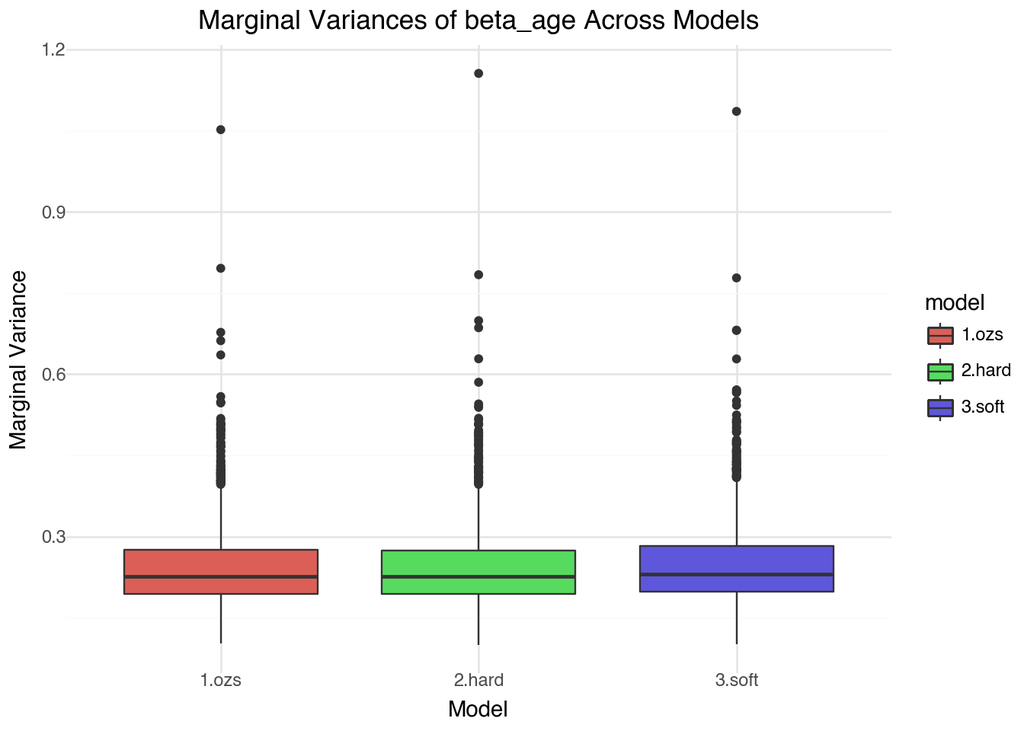

```python
from utils_dataviz import marginal_variances_boxplot
boxplot = marginal_variances_boxplot(
    ["1.ozs", "2.hard", "3.soft"],
    [brklyn_qns_vars_phi_ozs, brklyn_qns_vars_phi_hard, brklyn_qns_vars_phi_soft]
)
boxplot
```

All implementations provide the approximately the same marginal variances.

```
number of regions: 329
number of components: 1
islands? []
max number of neighbors per node: 12
mean number of neighbors per node: 5.860182370820668
```

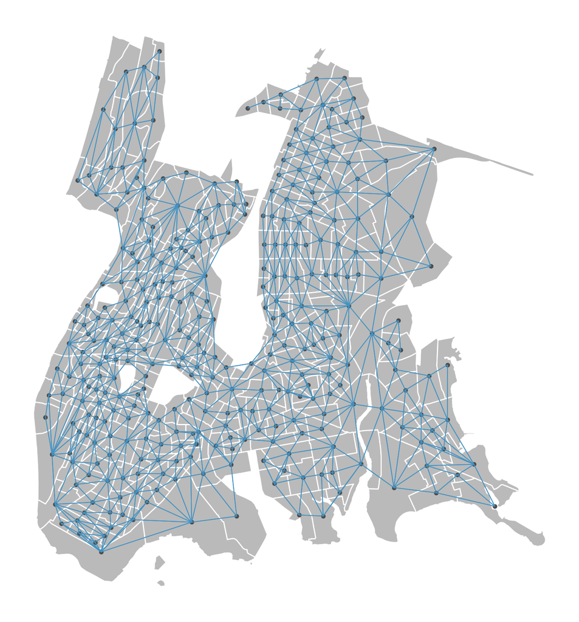

```python
bronx_gdf = nyc_gdf[nyc_gdf['comp_id']==1].reset_index(drop=True)
print(f'number of regions: {bronx_gdf.shape[0]}')
bronx_nbs = Queen.from_dataframe(bronx_gdf , geom_col='geometry')
plot_spatial_weights(bronx_nbs, bronx_gdf )

print(f'number of components: {bronx_nbs.n_components}')
print(f'islands? {bronx_nbs.islands}')
print(f'max number of neighbors per node: {bronx_nbs.max_neighbors}')
print(f'mean number of neighbors per node: {bronx_nbs.mean_neighbors}')
```

```python
# design matrix
design_vars = np.array(['pct_pubtransit','med_hh_inc', 'traffic', 'frag_index'])
design_mat = bronx_gdf[design_vars].to_numpy()
design_mat[:, 1] = np.log(design_mat[:, 1])
design_mat[:, 2] = np.log(design_mat[:, 2])

# neighbors array
bronx_nbs_adj = nbs_to_adjlist(bronx_nbs)

# scaling factor
tau = get_scaling_factor(bronx_nbs)

bronx_data = {"N":bronx_gdf.shape[0],
              "y":bronx_gdf['count'].astype('int'),
              "E":bronx_gdf['kid_pop'].astype('int'),
              "K":4,
              "xs":design_mat,
              "N_edges": bronx_nbs_adj.shape[1],
              "neighbors": bronx_nbs_adj,
              "tau": tau
}
```

```python
bronx_ozs_fit = bym2_ozs_mod.sample(data=bronx_data, iter_warmup=5000)

print("sum_to_zero_vector: runtimes in seconds, all chains")
bronx_ozs_fit.time
```

```
10:59:27 - cmdstanpy - INFO - CmdStan start processing
```

```
10:59:34 - cmdstanpy - INFO - CmdStan done processing.
```

```
sum_to_zero_vector: runtimes in seconds, all chains
```

```
[{'warmup': 6.202, 'sampling': 1.227, 'total': 7.429},
 {'warmup': 5.483, 'sampling': 1.226, 'total': 6.709},
 {'warmup': 5.418, 'sampling': 1.265, 'total': 6.683},
 {'warmup': 5.162, 'sampling': 1.262, 'total': 6.424}]
```

```python
a_seed = bronx_ozs_fit.metadata.cmdstan_config['seed']
```

```python
bronx_soft_fit = bym2_soft_mod.sample(data=bronx_data, iter_warmup=5000, seed=a_seed)

print("soft sum-to-zero: runtimes in seconds, all chains")
bronx_soft_fit.time
```

```
10:59:34 - cmdstanpy - INFO - CmdStan start processing
```

```
10:59:57 - cmdstanpy - INFO - CmdStan done processing.
```

```
soft sum-to-zero: runtimes in seconds, all chains
```

```
[{'warmup': 16.711, 'sampling': 4.315, 'total': 21.026},
 {'warmup': 15.697, 'sampling': 4.461, 'total': 20.158},
 {'warmup': 17.129, 'sampling': 4.256, 'total': 21.385},
 {'warmup': 18.384, 'sampling': 4.083, 'total': 22.467}]
```

```python
bronx_hard_fit = bym2_hard_mod.sample(data=bronx_data, iter_warmup=5000, seed=a_seed)

print("hard sum-to-zero: runtimes in seconds, all chains")
bronx_hard_fit.time
```

```
10:59:57 - cmdstanpy - INFO - CmdStan start processing
```

```
11:00:22 - cmdstanpy - INFO - CmdStan done processing.
```

```
hard sum-to-zero: runtimes in seconds, all chains
```

```
[{'warmup': 20.076, 'sampling': 4.581, 'total': 24.657},
 {'warmup': 17.521, 'sampling': 5.054, 'total': 22.575},
 {'warmup': 18.204, 'sampling': 4.99, 'total': 23.194},
 {'warmup': 19.224, 'sampling': 4.79, 'total': 24.014}]
```

```python
bronx_ozs_summary = bronx_ozs_fit.summary()
bronx_ozs_summary.index =  bronx_ozs_summary.index.astype(str) + "  a) ozs"
ozs_fit_time = bronx_ozs_fit.time
ozs_total_time = 0
for i in range(len(ozs_fit_time)):
    ozs_total_time += ozs_fit_time[i]['total']
bronx_ozs_summary['ESS/sec'] = bronx_ozs_summary['ESS_bulk']/ozs_total_time


bronx_hard_summary = bronx_hard_fit.summary()
bronx_hard_summary.index = bronx_hard_summary.index.astype(str) + "  b) hard"
hard_fit_time = bronx_hard_fit.time
hard_total_time = 0
for i in range(len(hard_fit_time)):
    hard_total_time += hard_fit_time[i]['total']
bronx_hard_summary['ESS/sec'] = bronx_hard_summary['ESS_bulk']/hard_total_time

bronx_soft_summary = bronx_soft_fit.summary()
bronx_soft_summary.index = bronx_soft_summary.index.astype(str) + "  c) soft"
soft_fit_time = bronx_soft_fit.time
soft_total_time = 0
for i in range(len(soft_fit_time)):
    soft_total_time += soft_fit_time[i]['total']
bronx_soft_summary['ESS/sec'] = bronx_soft_summary['ESS_bulk']/soft_total_time

bronx_fits_summary = pd.concat([bronx_ozs_summary, bronx_hard_summary, bronx_soft_summary])
```

```python
beta_summary = summarize_predictor(bronx_fits_summary, 'beta')
sigma_summary = summarize_predictor(bronx_fits_summary, 'sigma')
rho_summary = summarize_predictor(bronx_fits_summary, 'rho')

bronx_summary = pd.concat([beta_summary, sigma_summary, rho_summary])

display(HTML(style_dataframe(bronx_summary, 3).to_html()))
```

|  | Mean | StdDev | ESS_bulk | ESS/sec | R_hat |
| --- | --- | --- | --- | --- | --- |
| beta0 a) ozs | -4.45 | 0.04 | 1981.44 | 72.73 | 1.00 |
| beta0 b) hard | -4.45 | 0.04 | 1569.38 | 16.62 | 1.00 |
| beta0 c) soft | -4.45 | 0.04 | 1324.43 | 15.57 | 1.00 |
| beta_intercept a) ozs | -4.66 | 1.91 | 567.38 | 20.83 | 1.01 |
| beta_intercept b) hard | -4.44 | 1.90 | 347.66 | 3.68 | 1.01 |
| beta_intercept c) soft | -4.70 | 1.97 | 434.38 | 5.11 | 1.02 |
| betas[1] a) ozs | 0.74 | 0.46 | 752.62 | 27.62 | 1.00 |
| betas[1] b) hard | 0.76 | 0.45 | 821.26 | 8.70 | 1.00 |
| betas[1] c) soft | 0.74 | 0.46 | 983.80 | 11.57 | 1.00 |
| betas[2] a) ozs | -0.10 | 0.16 | 406.32 | 14.91 | 1.01 |
| betas[2] b) hard | -0.13 | 0.16 | 291.47 | 3.09 | 1.01 |
| betas[2] c) soft | -0.10 | 0.17 | 389.18 | 4.58 | 1.02 |
| betas[3] a) ozs | 0.07 | 0.05 | 1795.66 | 65.91 | 1.00 |
| betas[3] b) hard | 0.08 | 0.05 | 1087.34 | 11.51 | 1.00 |
| betas[3] c) soft | 0.07 | 0.05 | 1321.12 | 15.54 | 1.00 |
| betas[4] a) ozs | 0.04 | 0.03 | 1744.74 | 64.04 | 1.00 |
| betas[4] b) hard | 0.04 | 0.03 | 886.36 | 9.39 | 1.00 |
| betas[4] c) soft | 0.04 | 0.03 | 1053.76 | 12.39 | 1.01 |
| sigma a) ozs | 0.64 | 0.04 | 405.34 | 14.88 | 1.01 |
| sigma b) hard | 0.64 | 0.04 | 595.39 | 6.30 | 1.00 |
| sigma c) soft | 0.64 | 0.04 | 649.33 | 7.64 | 1.01 |
| rho a) ozs | 0.19 | 0.11 | 63.18 | 2.32 | 1.06 |
| rho b) hard | 0.18 | 0.10 | 148.57 | 1.57 | 1.02 |
| rho c) soft | 0.19 | 0.11 | 130.48 | 1.53 | 1.03 |

Compare the fitted values of spatial component `phi`, which has a sum-to-zero constraint.

```
ozs: marginal variances last elements phi [0.27 0.31 0.27 0.22 0.23]
hard: marginal variances last elements phi [0.26 0.31 0.26 0.21 0.24]
soft: marginal variances last elements phi [0.26 0.31 0.25 0.22 0.25]
```

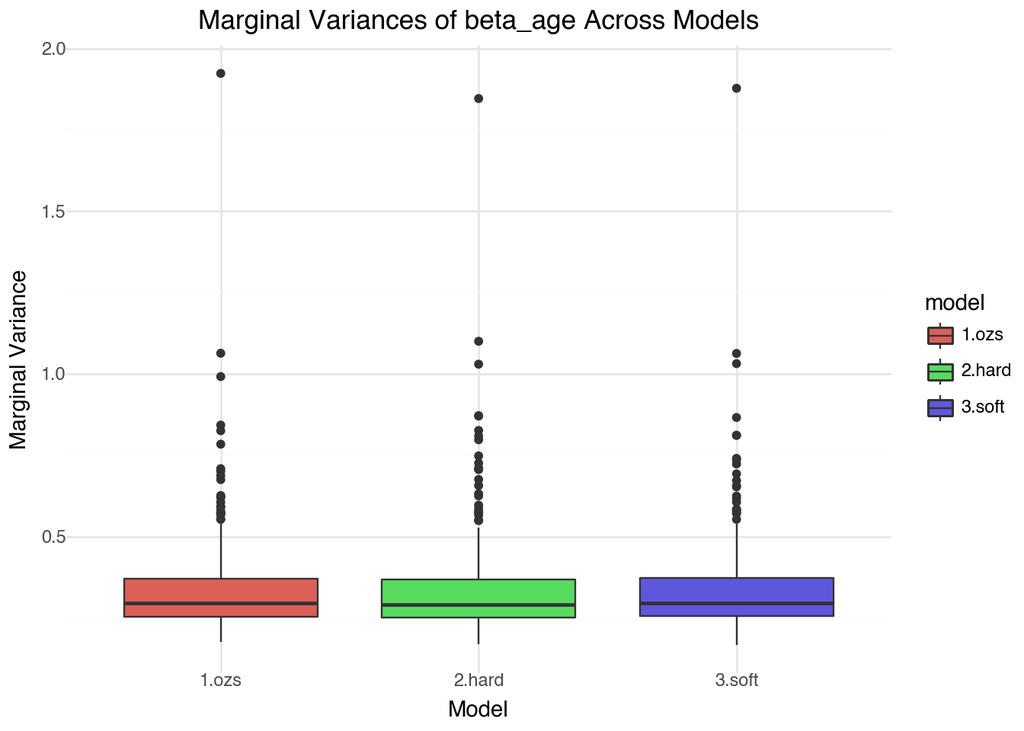

```python
bronx_phi_ozs = bronx_ozs_fit.stan_variable('phi')
bronx_phi_soft = bronx_hard_fit.stan_variable('phi')
bronx_phi_hard = bronx_soft_fit.stan_variable('phi')

bronx_vars_phi_ozs = np.var(bronx_phi_ozs, axis=0)
print('ozs: marginal variances last elements phi', bronx_vars_phi_ozs[-5:])

bronx_vars_phi_hard = np.var(bronx_phi_hard, axis=0)
print('hard: marginal variances last elements phi', bronx_vars_phi_hard[-5:])

bronx_vars_phi_soft = np.var(bronx_phi_soft, axis=0)
print('soft: marginal variances last elements phi', bronx_vars_phi_soft[-5:])


boxplot = marginal_variances_boxplot(
    ["1.ozs", "2.hard", "3.soft"],
    [bronx_vars_phi_ozs, bronx_vars_phi_hard, bronx_vars_phi_soft]
)
boxplot
```

#### Discussion

All implementations return almost identical estimates. The sum_to_zero_vector consistently has the fastest running time. The marginal variances of the spatial component `phi` are roughly the same across all models; presumably due to the fact that the ICAR prior is properly constraining the variances.

### Model 2: The BYM2_multicomp model, Freni-Sterrantino et al, 2018

In the previous section, we analyzed the New York City component-wise. This is highly unsatisfactory. In order to apply the BYM2 model to the full NYC dataset, it is necessary to extend the BYM2 model to account for disconnected components and singleton nodes.

This has been done by Freni-Sterrantino et al. in 2018 for INLA, and presented in: [A note on intrinsic Conditional Autoregressive models for disconnected graphs](https://arxiv.org/abs/1705.04854). They provide the following recommendations:

- Non-singleton nodes are given the BYM2 prior
- Singleton nodes (islands) are given a standard Normal prior
- Compute per-connected component scaling factor
- **Impose a sum-to-zero constraint on each connected component**

We have followed these recommendations and implemented this model in Stan. The full implementation details can be found in the notebook * [The BYM2_multicomp model in Stan](https://github.com/mitzimorris/geomed_2024/blob/main/python-notebooks/h6_bym2_multicomp.ipynb)

For this case study, we provide 2 implementations of the BYM2_multicomp model: one which uses the `sum_to_zero_vector` and one which implements the soft sum-to-zero constraint.

It is necessary to constrain the the elements of the spatial effects vector `phi` on a component-by-component basis. Stan’s [slicing with range indexes](https://mc-stan.org/docs/stan-users-guide/multi-indexing.html#slicing-with-range-indexes), provides a way to efficiently access each component. The helper function `nyc_sort_by_comp_size` both sorts the study data by component and adds the component index to the geodataframe.

In the BYM2 model for a fully connected graph the sum-to-zero constraint on `phi` is implemented directly by declaring `phi` to be a `sum_to_zero_vector`, which is a [constrained parameter type](https://mc-stan.org/docs/reference-manual/transforms.html#variable-transforms.chapter). The declaration:

```stan
  sum_to_zero_vector[N] phi;  // spatial effects
```

creates a *constrained* variable of length $N$, with a corresponding unconstrained variable of length $N-1$.

In order to constrain slices of the parameter vector `phi`, we do the following:

- In the `parameters` block, we declare the *unconstrained* parameter `phi_raw` as an regular vector `vector` (instead of a `sum_to_zero_vector`).
  - For a fully connected graph of size $N$, the size of the unconstrained sum-to-zero vector is $N-1$. For a disconnected graph with $M$ non-singleton nodes, the size of `phi_raw` is $M$ minus the number of connected components.

```stan
  vector[N_connected - N_components] phi_raw;  // spatial effects
```

- In the `functions` block, we implement the unconstraining transform.
- In the `transformed parameters` block, we apply the constraining transform.

```stan
  vector[N_connected] phi = zero_sum_components_lp(phi_raw, component_idxs, component_sizes);
```

The constraining transform is broken into two functions:

- function `zero_sum_constrain_lp`, the actual constraining transform, which corresponds directly to the built-in `zero_sum_vector` transform.
- function `zero_sum_constrain_components_lp`, which handles the slicing, and calls `zero_sum_constrain_lp` on each component.

```stan
  /**
   * Constrain sum-to-zero vector
   *
   * @param y unconstrained zero-sum parameters
   * @return vector z, the vector whose slices sum to zero
   */
  vector zero_sum_constrain_lp(vector y) {
    int N = num_elements(y);
    vector[N + 1] z = zeros_vector(N + 1);
    real sum_w = 0;
    for (ii in 1:N) {
      int i = N - ii + 1;
      real n = i;
      real w = y[i] * inv_sqrt(n * (n + 1));
      sum_w += w;
      z[i] += sum_w;
      z[i + 1] -= w * n;
    }
    return z;
  }
```

- `zero_sum_components_lp`: slices vector `phi` by component, applies constraining transform to each.

```stan
  /**
   * Component-wise constrain sum-to-zero vectors
   *
   * @param phi unconstrained vector of zero-sum slices
   * @param idxs component start and end indices
   * @param sizes component sizes
   * @return vector phi_ozs, the vector whose slices sum to zero
   */
  vector zero_sum_components_lp(vector phi,
                                array[ , ] int idxs,
                                array[] int sizes) {
    vector[sum(sizes)] phi_ozs;
    int idx_phi = 1;
    int idx_ozs = 1;
    for (i in 1:size(sizes)) {
      phi_ozs[idx_ozs : idx_ozs + sizes[i] - 1] =
        zero_sum_constrain_lp(segment(phi, idx_phi, sizes[i] - 1));
      idx_phi += sizes[i] - 1;
      idx_ozs += sizes[i];
    }
    return phi_ozs;
  }
```

#### Data Assembly

The helper function `nyc_soft_by_comp_size` adds component info to the geodataframe. It also returns the neighbor graph over the full dataset, plus a list of component sizes.

```python
from utils_nyc_map import nyc_sort_by_comp_size
from utils_bym2 import nbs_to_adjlist, get_scaling_factors

(nyc_nbs, nyc_gdf, nyc_comp_sizes) = nyc_sort_by_comp_size(nyc_geodata)

# design matrix
design_vars = np.array(['pct_pubtransit','med_hh_inc', 'traffic', 'frag_index'])
design_mat = nyc_gdf[design_vars].to_numpy()
design_mat[:, 1] = np.log(design_mat[:, 1])
design_mat[:, 2] = np.log(design_mat[:, 2])

# spatial structure
nyc_nbs_adj = nbs_to_adjlist(nyc_nbs)
component_sizes = [x for x in nyc_comp_sizes if x > 1]
scaling_factors = get_scaling_factors(len(component_sizes), nyc_gdf)
```

We assemble all inputs into dictionary `bym2_multicomp_data`.

```python
bym2_multicomp_data = {
    "N":nyc_gdf.shape[0],
    "y":nyc_gdf['count'].astype('int'),
    "E":nyc_gdf['kid_pop'].astype('int'),
    "K":4,
    "xs":design_mat,
    "N_edges": nyc_nbs_adj.shape[1],
    "neighbors": nyc_nbs_adj,
    "N_components": len(component_sizes),
    "component_sizes": component_sizes,
    "scaling_factors": scaling_factors
}
```

#### Model Fitting

```python
bym2_multicomp_ozs_file = os.path.join('stan', 'bym2_multicomp.stan')
bym2_multicomp_ozs_mod = CmdStanModel(stan_file=bym2_multicomp_ozs_file)
```

```python
bym2_multicomp_ozs_fit = bym2_multicomp_ozs_mod.sample(data=bym2_multicomp_data, iter_warmup=3000)

print("sum_to_zero_vector: runtimes in seconds, all chains")
bym2_multicomp_ozs_fit.time
```

```
11:00:34 - cmdstanpy - INFO - CmdStan start processing
```

```
11:01:50 - cmdstanpy - INFO - CmdStan done processing.
```

```
sum_to_zero_vector: runtimes in seconds, all chains
```

```
[{'warmup': 59.555, 'sampling': 14.002, 'total': 73.557},
 {'warmup': 56.93, 'sampling': 14.155, 'total': 71.085},
 {'warmup': 59.212, 'sampling': 13.836, 'total': 73.048},
 {'warmup': 60.161, 'sampling': 15.154, 'total': 75.315}]
```

```python
bym2_multicomp_ozs_summary = bym2_multicomp_ozs_fit.summary()
ozs_fit_time = bym2_multicomp_ozs_fit.time
ozs_total_time = 0
for i in range(len(ozs_fit_time)):
    ozs_total_time += ozs_fit_time[i]['total']
bym2_multicomp_ozs_summary['ESS/sec'] = bym2_multicomp_ozs_summary['ESS_bulk']/ozs_total_time

bym2_multicomp_ozs_summary[['Mean', 'StdDev', 'ESS_bulk', 'ESS/sec', 'R_hat']].round(2).loc[
  ['beta_intercept', 'beta0', 'betas[1]', 'betas[2]', 'betas[3]', 'betas[4]', 'sigma', 'rho']]
```

|  | Mean | StdDev | ESS_bulk | ESS/sec | R_hat |
| --- | --- | --- | --- | --- | --- |
| beta_intercept | -5.77 | 0.56 | 870.54 | 2.97 | 1.00 |
| beta0 | -4.48 | 0.02 | 1751.87 | 5.98 | 1.00 |
| betas[1] | 0.81 | 0.16 | 655.54 | 2.24 | 1.01 |
| betas[2] | 0.04 | 0.05 | 780.65 | 2.66 | 1.00 |
| betas[3] | 0.03 | 0.02 | 1377.75 | 4.70 | 1.00 |
| betas[4] | 0.04 | 0.01 | 777.33 | 2.65 | 1.00 |
| sigma | 0.78 | 0.02 | 241.01 | 0.82 | 1.01 |
| rho | 0.39 | 0.06 | 166.03 | 0.57 | 1.02 |

#### Model Comparison

We can compare the `sum_to_zero_vector` implementation to an implementation of the soft sum-to-zero constraint. In the `bym2_soft.stan` model, the soft sum-to-zero constraint is combined directly with the ICAR prior:

```stan
  target += (-0.5 * dot_self(phi[neighbors[1]] - phi[neighbors[2]])
         + normal_lupdf(sum(phi) | 0, 0.001 * rows(phi)));
```

For the BYM2_multicomp model, split this into two parts. The ICAR prior is applied to `phi`, and then we iterate through the components, applying the sum-to-zero constraint to each in turn.

```stan
  target += -0.5 * dot_self(phi[neighbors[1]] - phi[neighbors[2]]);  // ICAR
  for (n in 1:N_components) {   // component-wise sum-to-zero constraint
    sum(phi[node_idxs[n, 1] : node_idxs[n, 2]]) ~ normal(0,
                             0.001 * component_sizes[n]);
```

The data inputs are the same. To ensure (roughly) the same initialization, we reuse the seed from `bym2_multicomp_ozs_fit`.

```python
a_seed = bym2_multicomp_ozs_fit.metadata.cmdstan_config['seed']
```

```python
bym2_multicomp_soft_file = os.path.join('stan', 'bym2_multicomp_soft.stan')
bym2_multicomp_soft_mod = CmdStanModel(stan_file=bym2_multicomp_soft_file)
```

This model fits *very* slowly and requires increasing the `max_treedepth`; at the default setting, all iterations hit this limit.

```python
bym2_multicomp_soft_fit = bym2_multicomp_soft_mod.sample(data=bym2_multicomp_data, iter_warmup=3000, max_treedepth=14, seed=a_seed)

print("soft sum-to-zero: runtimes in seconds, all chains")
bym2_multicomp_soft_fit.time
```

```
11:02:15 - cmdstanpy - INFO - CmdStan start processing
```

```
11:19:46 - cmdstanpy - INFO - CmdStan done processing.
```

```
soft sum-to-zero: runtimes in seconds, all chains
```

```
[{'warmup': 762.715, 'sampling': 256.787, 'total': 1019.5},
 {'warmup': 783.97, 'sampling': 256.537, 'total': 1040.51},
 {'warmup': 798.797, 'sampling': 251.954, 'total': 1050.75},
 {'warmup': 784.326, 'sampling': 254.302, 'total': 1038.63}]
```

```python
bym2_multicomp_soft_summary = bym2_multicomp_soft_fit.summary()
```

We compare the result of both implementations.

```python
bym2_multicomp_ozs_summary.index =  bym2_multicomp_ozs_summary.index.astype(str) + "  a) ozs"

bym2_multicomp_soft_summary.index =  bym2_multicomp_soft_summary.index.astype(str) + "  b) soft"
soft_fit_time = bym2_multicomp_soft_fit.time
soft_total_time = 0
for i in range(len(soft_fit_time)):
    soft_total_time += soft_fit_time[i]['total']
bym2_multicomp_soft_summary['ESS/sec'] = bym2_multicomp_soft_summary['ESS_bulk']/soft_total_time

bym2_multicomp_summary = pd.concat([bym2_multicomp_ozs_summary, bym2_multicomp_soft_summary])

beta_summary = summarize_predictor(bym2_multicomp_summary, 'beta')
sigma_summary = summarize_predictor(bym2_multicomp_summary, 'sigma')
rho_summary = summarize_predictor(bym2_multicomp_summary, 'rho')
nyc_summary = pd.concat([beta_summary, sigma_summary, rho_summary])
```

```python
display(HTML(style_dataframe(nyc_summary, 2).to_html()))
```

|  | Mean | StdDev | ESS_bulk | ESS/sec | R_hat |
| --- | --- | --- | --- | --- | --- |
| beta0 a) ozs | -4.48 | 0.02 | 1751.87 | 5.98 | 1.00 |
| beta0 b) soft | -4.48 | 0.02 | 1553.34 | 0.37 | 1.00 |
| beta_intercept a) ozs | -5.77 | 0.56 | 870.54 | 2.97 | 1.00 |
| beta_intercept b) soft | -5.77 | 0.58 | 673.47 | 0.16 | 1.00 |
| betas[1] a) ozs | 0.81 | 0.16 | 655.54 | 2.24 | 1.01 |
| betas[1] b) soft | 0.81 | 0.16 | 616.78 | 0.15 | 1.00 |
| betas[2] a) ozs | 0.04 | 0.05 | 780.65 | 2.66 | 1.00 |
| betas[2] b) soft | 0.04 | 0.05 | 612.20 | 0.15 | 1.00 |
| betas[3] a) ozs | 0.03 | 0.02 | 1377.75 | 4.70 | 1.00 |
| betas[3] b) soft | 0.03 | 0.02 | 1313.91 | 0.32 | 1.00 |
| betas[4] a) ozs | 0.04 | 0.01 | 777.33 | 2.65 | 1.00 |
| betas[4] b) soft | 0.04 | 0.01 | 672.40 | 0.16 | 1.00 |
| sigma a) ozs | 0.78 | 0.02 | 241.01 | 0.82 | 1.01 |
| sigma b) soft | 0.77 | 0.02 | 266.93 | 0.06 | 1.03 |
| rho a) ozs | 0.39 | 0.06 | 166.03 | 0.57 | 1.02 |
| rho b) soft | 0.38 | 0.05 | 125.68 | 0.03 | 1.04 |

### Discussion

The BYM2 model has more data and a relatively complex multilevel structure. Before Stan 2.36, for this model and dataset, the soft sum-to-zero constraint was much faster than the hard sum-to-zero constraint. Here we show that the `sum_to_zero_vector` greatly improves the run time.

Although the `ESS_bulk` numbers for the both implmentations are roughly comparable, the `ESS_sec` for the `sum_to_zero_vector` implementation is over 12 times faster.

## Conclusion: the `sum_to_zero_vector` just works!

The more complex the model, the greater the need for the `sum_to_zero_vector`.

## References

- Seybolt, 2024: [Add ZeroSumNormal distribution](https://github.com/pyro-ppl/numpyro/pull/1751#issuecomment-1980569811)
- Gelman and Carpenter, 2020: [Bayesian Analysis of Tests with Unknown Specificity and Sensitivity](https://doi.org/10.1111/rssc.12435)
- Riebler et al., 2016: [An intuitive Bayesian spatial model for disease mapping that accounts for scaling](https://arxiv.org/abs/1601.01180)
- Freni-Sterrantino et al.,2018: [A note on intrinsic conditional autoregressive models for disconnected graphs](https://arxiv.org/pdf/1705.04854.pdf)
- Morris et al., 2019: [Bayesian Hierarchical Spatial Models: Implementing the Besag York Mollié Model in Stan](https://www.sciencedirect.com/science/article/abs/pii/S1877584518301175)
- Stan Development Team: [Stan Documentation Suite](https://mc-stan.org/docs/)